# ADP replication and women’s empowerment extension: analysis pipeline

## 9.4b Robustness: standard errors clustered by district

The main standard errors are clustered by matched set. As a check, the main specification (full matching, unadjusted) is re-estimated with standard errors clustered by district, with a t distribution on (number of districts - 1) degrees of freedom. The ATTs are identical; only the standard errors and p-values change. Benjamini-Hochberg within the nine estimates of each sample.

```r
emp_cluster_dist <- bind_rows(lapply(SAMPLES_09, function(s) {
  m <- matched[[paste(s, "full", sep = "__")]]
  bind_rows(lapply(seq_len(nrow(EMP_ESTIMATES)), function(i) {
    pop <- EMP_ESTIMATES$population[i]; v <- EMP_ESTIMATES$var[i]
    att_did(m, filter(panel_e, population == pop), v, cluster_var = "dist_id") %>% mutate(population = pop)
  })) %>% mutate(sample = s, p_bh = p.adjust(p_value, method = "BH"))
})) %>% mutate(label = EMP_LABELS[outcome])

## Check: the ATTs equal the main results; only the standard errors differ
chk_cd <- emp_cluster_dist %>%
  inner_join(emp_main %>% filter(version == "unadjusted") %>%
               select(sample, population, outcome, att_main = att, se_main = se, p_main = p_value),
             by = c("sample", "population", "outcome"))
stopifnot(nrow(chk_cd) == nrow(emp_cluster_dist), max(abs(chk_cd$att - chk_cd$att_main)) < 1e-8)
print(chk_cd %>% select(sample, population, label, att, se_main, p_main, se_district = se,
                        p_district = p_value, p_bh_district = p_bh, clusters) %>%
        mutate(across(where(is.numeric), ~ round(.x, 3))), n = Inf, width = Inf)
```

```
## # A tibble: 18 × 10
##    sample   population    label                          att se_main p_main se_district p_district p_bh_district clusters
##    <chr>    <chr>         <chr>                        <dbl>   <dbl>  <dbl>       <dbl>      <dbl>         <dbl>    <dbl>
##  1 full     married_15_49 Decision-making index (SD)  -0.011   0.03   0.71        0.037      0.764         0.764      570
##  2 full     married_15_49 Barrier index (SD)           0.051   0.045  0.262       0.047      0.273         0.487      570
##  3 full     married_15_49 Water time (minutes)         0.588   0.502  0.246       0.597      0.325         0.487      570
##  4 full     married_15_49 Water within 30 min (share) -0.011   0.006  0.093       0.007      0.129         0.487      570
##  5 full     women_15_24   Decision-making index (SD)   0.032   0.076  0.68        0.071      0.654         0.736      567
##  6 full     women_15_24   Barrier index (SD)           0.056   0.049  0.257       0.049      0.253         0.487      570
##  7 full     women_15_24   Education (years)           -0.149   0.116  0.201       0.106      0.157         0.487      570
##  8 full     women_15_24   Water time (minutes)         0.544   0.535  0.313       0.633      0.391         0.502      570
##  9 full     women_15_24   Water within 30 min (share) -0.008   0.007  0.239       0.008      0.313         0.487      570
## 10 precovid married_15_49 Decision-making index (SD)  -0.086   0.056  0.136       0.069      0.214         0.543      260
## 11 precovid married_15_49 Barrier index (SD)           0.117   0.103  0.265       0.1        0.241         0.543      260
## 12 precovid married_15_49 Water time (minutes)        -0.26    0.537  0.632       0.605      0.667         0.78       260
## 13 precovid married_15_49 Water within 30 min (share) -0.002   0.005  0.637       0.006      0.686         0.78       260
## 14 precovid women_15_24   Decision-making index (SD)  -0.174   0.081  0.04        0.093      0.063         0.411      257
## 15 precovid women_15_24   Barrier index (SD)           0.161   0.102  0.123       0.095      0.091         0.411      260
## 16 precovid women_15_24   Education (years)           -0.021   0.11   0.853       0.133      0.877         0.877      260
## 17 precovid women_15_24   Water time (minutes)        -0.267   0.692  0.702       0.677      0.694         0.78       260
## 18 precovid women_15_24   Water within 30 min (share) -0.003   0.006  0.635       0.006      0.643         0.78       260
```

```r
write_csv(emp_cluster_dist, file.path(TABLE_DIR, "att_cluster_district.csv"))
```

## 9.5 Helpers for the robustness checks

`estimate_all()` runs every health and empowerment estimate on one matched sample, with BH within each family. `subclass_weights()` rebuilds the full-matching ATT weights from subclass membership: each AD weight 1, each non-AD (ADs in its subclass) / (non-ADs in its subclass), rescaled so control weights sum to the number of controls (as MatchIt does). It is needed when districts are removed (leave one state out) or labels are shuffled (permutation), and it is checked against the Stage 08 weights first.

```r
estimate_all <- function(m, adj = character(0)) {
  h <- bind_rows(lapply(HEALTH_OUTCOMES$var, function(v) att_did(m, panel_h, v, adjust = adj))) %>%
    mutate(family = "health", population = "children/mothers", p_bh = p.adjust(p_value, method = "BH"))
  e <- bind_rows(lapply(seq_len(nrow(EMP_ESTIMATES)), function(i)
      att_did(m, filter(panel_e, population == EMP_ESTIMATES$population[i]), EMP_ESTIMATES$var[i],
              adjust = adj) %>% mutate(population = EMP_ESTIMATES$population[i]))) %>%
    mutate(family = "empowerment", p_bh = p.adjust(p_value, method = "BH"))
  bind_rows(h, e)
}
## Index outcomes only (decision-making and barrier indices, both populations), for Stage 10,
## where only these two outcomes change. Same estimator and order as estimate_all(); no BH
## column, because Stage 10 robustness reports raw p-values only.
INDEX_VARS <- c("decision_index", "barrier_index")
estimate_index <- function(m, adj = character(0)) {
  ix <- which(EMP_ESTIMATES$var %in% INDEX_VARS)
  bind_rows(lapply(ix, function(i)
      att_did(m, filter(panel_e, population == EMP_ESTIMATES$population[i]), EMP_ESTIMATES$var[i],
              adjust = adj) %>% mutate(population = EMP_ESTIMATES$population[i]))) %>%
    mutate(family = "empowerment")
}
label_of <- function(outcome, family)
  ifelse(family == "health", HEALTH_OUTCOMES$label[match(outcome, HEALTH_OUTCOMES$var)], EMP_LABELS[outcome])
no_of <- function(outcome) HEALTH_OUTCOMES$no[match(outcome, HEALTH_OUTCOMES$var)]
## Panel title and order for figures: health in A&M order (with indicator number), then empowerment
panel_of <- function(family, population, outcome) {
  title <- ifelse(family == "health", paste(no_of(outcome), label_of(outcome, family)),
                  paste0(label_of(outcome, family), ", ", sub("_(\\d+)_(\\d+)$", " \\1-\\2", population)))
  ord <- ifelse(family == "health", match(outcome, HEALTH_OUTCOMES$var),
                100 + match(paste(population, outcome), paste(EMP_ESTIMATES$population, EMP_ESTIMATES$var)))
  factor(title, levels = unique(title[order(ord)]))
}

subclass_weights <- function(adp, subclass) {
  n_t <- ave(adp, subclass, FUN = sum); n_c <- ave(1 - adp, subclass, FUN = sum)
  w <- ifelse(adp == 1, 1, n_t / n_c)
  ctrl <- adp == 0
  w[ctrl] <- w[ctrl] * sum(ctrl) / sum(w[ctrl])
  w
}
ess <- function(w) sum(w)^2 / sum(w^2)   # effective sample size of a set of weights

## Check: rebuilt weights equal the Stage 08 weights for every matched sample
w_check <- sapply(matched, function(m) max(abs(subclass_weights(m$adp_flag, m$subclass) - m$weights)))
print(signif(w_check, 3))
```

```
##        full__full     full__full_cs     full__nearest     full__genetic    precovid__full precovid__full_cs precovid__nearest precovid__genetic
##          1.78e-15          2.22e-16          0.00e+00          0.00e+00          5.55e-17          3.55e-15          0.00e+00          0.00e+00
```

```r
stopifnot(all(w_check < 1e-8))
```

## 9.6 Robustness: alternative matching (A&M Tables 9 and 10)

Common support (`full_cs`), nearest neighbour 3:1 and genetic 3:1, unadjusted, for all outcomes in both samples. Together with 9.3 and 9.4 this gives one long table of every estimate (`att_all`).

```r
robust_match <- bind_rows(lapply(SAMPLES_09, function(s) bind_rows(lapply(c("full_cs", "nearest", "genetic"),
  function(sp) estimate_all(matched[[paste(s, sp, sep = "__")]]) %>%
    mutate(sample = s, spec = sp, version = "unadjusted")))))

att_all <- bind_rows(
    health_main %>% mutate(family = "health", population = "children/mothers"),
    emp_main %>% mutate(family = "empowerment"),
    robust_match) %>%
  mutate(no = no_of(outcome), label = label_of(outcome, family),
         spec_label = case_when(spec == "full" & version == "unadjusted" ~ "Main (full matching)",
                                spec == "full" & version == "adjusted" ~ "Main, adjusted",
                                spec == "full_cs" ~ "Common support",
                                spec == "nearest" ~ "Nearest neighbour 3:1",
                                spec == "genetic" ~ "Genetic 3:1")) %>%
  select(sample, family, population, outcome, no, label, spec, version, spec_label,
         n_ad, n_non_ad, att, se, t_stat, p_value, p_bh, clusters, mean_change_ad, mean_change_non_ad,
         adjust_vars)

## Compact view: ATT (p-value) by specification
compact <- function(d) d %>%
  mutate(cell = sprintf("%.3f (%.3f)", att, p_value)) %>%
  select(sample, family, population, label, spec_label, cell) %>%
  tidyr::pivot_wider(names_from = spec_label, values_from = cell)
for (s in SAMPLES_09) {
  cat("\n==", s, "sample: ATT (p-value) ==\n")
  print(compact(filter(att_all, sample == s)) %>% select(-sample), n = Inf, width = Inf)
}
```

```
##
## == full sample: ATT (p-value) ==
## # A tibble: 22 × 8
##    family      population       label                                                          `Main (full matching)` `Main, adjusted` `Common support` `Nearest neighbour 3:1`
##    <chr>       <chr>            <chr>                                                          <chr>                  <chr>            <chr>            <chr>
##  1 health      children/mothers Registered pregnancies with a Mother and Child Protection card -1.819 (0.175)         -1.454 (0.192)   -2.081 (0.144)   0.370 (0.735)
##  2 health      children/mothers Mothers who consumed IFA for 100 days or more in pregnancy     -2.644 (0.263)         -1.630 (0.408)   -1.979 (0.413)   2.776 (0.058)
##  3 health      children/mothers Sex ratio at birth, children born in the last five years       -15.602 (0.540)        -14.252 (0.509)  -2.772 (0.907)   -16.609 (0.286)
##  4 health      children/mothers Home births conducted by skilled health personnel              -0.327 (0.467)         -0.295 (0.504)   -0.254 (0.568)   0.323 (0.367)
##  5 health      children/mothers Children under 3 breastfed within one hour of birth            -4.691 (0.032)         -4.602 (0.032)   -5.157 (0.019)   -4.289 (0.009)
##  6 health      children/mothers Children under 5 who are underweight                           1.422 (0.266)          1.545 (0.207)    1.155 (0.391)    -0.311 (0.704)
##  7 health      children/mothers Children with diarrhoea who received ORS                       2.847 (0.427)          2.786 (0.417)    3.058 (0.418)    1.756 (0.499)
##  8 health      children/mothers Children with diarrhoea who received zinc                      2.189 (0.446)          1.925 (0.503)    1.662 (0.575)    2.131 (0.358)
##  9 health      children/mothers Children with fever or ARI taken to a facility or provider     -2.125 (0.488)         -1.891 (0.524)   -1.746 (0.568)   0.261 (0.894)
## 10 health      children/mothers Breastfed children 6-23 months with an adequate diet           -1.550 (0.211)         -1.342 (0.243)   -1.515 (0.238)   0.010 (0.990)
```

[output cut: 87 more lines]

```r
write_csv(att_all, file.path(TABLE_DIR, "att_all_specifications.csv"))
```

## 9.7 Comparison with A&M Tables 5, 8, 9 and 10

A&M’s estimates typed from the paper (Economics and Human Biology 54, 2024, 101411). Tables 9 and 10 report only indicators significant at 10%; the rest are in A&M’s online appendix (S4, S6, S8, S10), which we do not have, so they show as missing. A&M’s p-values are printed to 2 decimals (0.00 means below 0.005). A&M’s full matching is compared with both our main estimate (all ADs) and our common-support version (A&M-style). ORS, zinc, fever and 10.2 are flagged: A&M’s NFHS-5 values for these contradict the official reports.

```r
AM <- tibble::tribble(
  ~am_sample, ~am_spec, ~no, ~am_est, ~am_se, ~am_p, ~am_p_bh,
  ## Table 5: full sample, full matching
  "full", "full", "1.3",  -0.13,  1.44, 0.93, 0.93,
  "full", "full", "2",     0.28,  1.98, 0.89, 0.93,
  "full", "full", "4.1",   8.84, 18.39, 0.63, 0.93,
  "full", "full", "5",    -0.52,  0.58, 0.38, 0.81,
  "full", "full", "6.1",  -6.34,  2.48, 0.01, 0.14,
  "full", "full", "7",    -3.22,  3.11, 0.30, 0.81,
  "full", "full", "8.2",  -5.33,  5.42, 0.33, 0.81,
  "full", "full", "8.3",  -1.07,  3.21, 0.74, 0.93,
  "full", "full", "8.4",  -6.21,  5.45, 0.25, 0.81,
  "full", "full", "10.1",  0.30,  1.21, 0.81, 0.93,
  "full", "full", "10.2", -7.50,  6.43, 0.24, 0.81,
  "full", "full", "11a",  -0.43,  2.99, 0.88, 0.93,
  "full", "full", "11b",  -1.53,  2.27, 0.50, 0.93,
  ## Table 8: pre-COVID, full matching
  "precovid", "full", "1.3",   2.57,  1.92, 0.18, 0.80,
  "precovid", "full", "2",     2.94,  2.93, 0.32, 0.80,
  "precovid", "full", "4.1", -23.70, 37.14, 0.52, 0.80,
  "precovid", "full", "5",    -0.47,  0.81, 0.56, 0.80,
  "precovid", "full", "6.1",   1.02,  3.57, 0.78, 0.84,
  "precovid", "full", "7",    -3.87,  1.95, 0.05, 0.62,
  "precovid", "full", "8.2",   7.15,  9.86, 0.47, 0.80,
  "precovid", "full", "8.3",   8.69,  6.60, 0.19, 0.80,
  "precovid", "full", "8.4",  -3.26,  7.19, 0.65, 0.80,
  "precovid", "full", "10.1", -0.79,  1.90, 0.68, 0.80,
  "precovid", "full", "10.2", -2.59,  5.79, 0.65, 0.80,
  "precovid", "full", "11a",   0.57,  3.39, 0.87, 0.87,
  "precovid", "full", "11b",  -2.77,  4.41, 0.53, 0.80,
  ## Table 9: full sample, alternative matching (significant indicators only)
  "full", "nearest", "6.1",   -3.81, 1.72, 0.03, 0.36,
  "full", "genetic", "6.1",   -4.80, 1.65, 0.00, 0.05,
  ## Table 10: pre-COVID, alternative matching (significant indicators only)
  "precovid", "nearest", "2",  5.42, 3.13, 0.08, 0.57,
  "precovid", "nearest", "7", -2.23, 1.30, 0.09, 0.57,
  "precovid", "genetic", "7", -3.05, 0.96, 0.00, 0.02)
AM_N <- tibble::tribble(~am_sample, ~am_spec, ~am_n_ad, ~am_n_non_ad,
  "full", "full", 92, 389, "full", "nearest", 97, 291, "full", "genetic", 97, 291,
  "precovid", "full", 28, 185, "precovid", "nearest", 30, 90, "precovid", "genetic", 30, 90)

am_compare <- att_all %>%
  filter(family == "health", version == "unadjusted") %>%
  mutate(am_spec = if_else(spec == "full_cs", "full", spec)) %>%
  left_join(AM, by = c("sample" = "am_sample", "am_spec", "no")) %>%
  left_join(AM_N, by = c("sample" = "am_sample", "am_spec")) %>%
  mutate(same_sign = sign(att) == sign(am_est),
         sig5_ours = p_value < 0.05, sig5_am = am_p < 0.05,
         am_contradicts_official = no %in% c("8.2", "8.3", "8.4", "10.2")) %>%
  select(sample, spec_label, no, label, n_ad, n_non_ad, att, se, p_value, p_bh,
         am_n_ad, am_n_non_ad, am_est, am_se, am_p, am_p_bh, same_sign, sig5_ours, sig5_am,
         am_contradicts_official)

for (s in SAMPLES_09) for (sl in c("Main (full matching)", "Common support", "Nearest neighbour 3:1", "Genetic 3:1")) {
  cat("\n==", s, "|", sl, "vs A&M ==\n")
  print(am_compare %>% filter(sample == s, spec_label == sl) %>%
          transmute(no, ours = sprintf("%.2f (%.2f) p=%.3f", att, se, p_value),
                    am = ifelse(is.na(am_est), "not in main text", sprintf("%.2f (%.2f) p=%.2f", am_est, am_se, am_p)),
                    same_sign, sig5_ours, sig5_am, flag_58 = am_contradicts_official), n = Inf)
}
```

```
##
## == full | Main (full matching) vs A&M ==
## # A tibble: 13 × 7
##    no    ours                   am                  same_sign sig5_ours sig5_am flag_58
##    <chr> <chr>                  <chr>               <lgl>     <lgl>     <lgl>   <lgl>
##  1 1.3   -1.82 (1.33) p=0.175   -0.13 (1.44) p=0.93 TRUE      FALSE     FALSE   FALSE
##  2 2     -2.64 (2.34) p=0.263   0.28 (1.98) p=0.89  FALSE     FALSE     FALSE   FALSE
##  3 4.1   -15.60 (25.32) p=0.540 8.84 (18.39) p=0.63 FALSE     FALSE     FALSE   FALSE
##  4 5     -0.33 (0.45) p=0.467   -0.52 (0.58) p=0.38 TRUE      FALSE     FALSE   FALSE
##  5 6.1   -4.69 (2.15) p=0.032   -6.34 (2.48) p=0.01 TRUE      TRUE      TRUE    FALSE
##  6 7     1.42 (1.27) p=0.266    -3.22 (3.11) p=0.30 FALSE     FALSE     FALSE   FALSE
##  7 8.2   2.85 (3.57) p=0.427    -5.33 (5.42) p=0.33 FALSE     FALSE     FALSE   TRUE
##  8 8.3   2.19 (2.86) p=0.446    -1.07 (3.21) p=0.74 FALSE     FALSE     FALSE   TRUE
##  9 8.4   -2.13 (3.05) p=0.488   -6.21 (5.45) p=0.25 TRUE      FALSE     FALSE   TRUE
## 10 10.1  -1.55 (1.23) p=0.211   0.30 (1.21) p=0.81  FALSE     FALSE     FALSE   FALSE
```

[output cut: 129 more lines]

```r
cat("\nRows with an A&M estimate:", sum(!is.na(am_compare$am_est)),
    "| same sign:", sum(am_compare$same_sign, na.rm = TRUE),
    "| same 5% significance:", sum(am_compare$sig5_ours == am_compare$sig5_am, na.rm = TRUE), "\n")
```

```
##
## Rows with an A&M estimate: 57 | same sign: 37 | same 5% significance: 53
```

```r
write_csv(am_compare, file.path(TABLE_DIR, "att_compare_am.csv"))
```

## 9.8 Robustness: trimming the largest control weights

```r
trim_weights <- function(m, pct) {
  ctrl <- m$adp_flag == 0
  cap <- unname(quantile(m$weights[ctrl], 1 - pct / 100))
  m$weights[ctrl] <- pmin(m$weights[ctrl], cap)
  m
}
trim_results <- list(); trim_info <- list()
for (s in SAMPLES_09) for (pct in c(1, 5)) {
  m0 <- matched[[paste(s, "full", sep = "__")]]; m1 <- trim_weights(m0, pct)
  ctrl <- m0$adp_flag == 0
  trim_info[[length(trim_info) + 1]] <- tibble(sample = s, trim_pct = pct,
    cap = max(m1$weights[ctrl]), controls_capped = sum(m0$weights[ctrl] > max(m1$weights[ctrl])),
    top10_weight_share = sum(sort(m0$weights[ctrl], decreasing = TRUE)[1:10]) / sum(m0$weights[ctrl]),
    ess_before = ess(m0$weights[ctrl]), ess_after = ess(m1$weights[ctrl]))
  trim_results[[length(trim_results) + 1]] <- estimate_all(m1) %>% mutate(sample = s, trim_pct = pct)
}
trim_info <- bind_rows(trim_info); print(trim_info %>% mutate(across(where(is.numeric), ~ round(.x, 2))))
```

```
## # A tibble: 4 × 7
##   sample   trim_pct   cap controls_capped top10_weight_share ess_before ess_after
##   <chr>       <dbl> <dbl>           <dbl>              <dbl>      <dbl>     <dbl>
## 1 full            1 13.8                2               0.36       40.5      78.2
## 2 full            5  4.59              12               0.36       40.5     133.
## 3 precovid        1 18.9                3               0.52       18.7      28.4
## 4 precovid        5  1.83              10               0.52       18.7     118.
```

```r
trim_table <- bind_rows(trim_results) %>%
  mutate(label = label_of(outcome, family)) %>%
  select(sample, family, population, outcome, label, trim_pct, att, se, p_value) %>%
  left_join(att_all %>% filter(spec == "full", version == "unadjusted") %>%
              select(sample, family, population, outcome, att_main = att, p_main = p_value),
            by = c("sample", "family", "population", "outcome")) %>%
  mutate(sign_flip = sign(att) != sign(att_main),
         sig_change = (p_value < 0.05) != (p_main < 0.05),
         pct_change = 100 * (att - att_main) / abs(att_main))
cat("\nEstimates whose sign flips or 5% significance changes under trimming:\n")
```

```
##
## Estimates whose sign flips or 5% significance changes under trimming:
```

```r
print(trim_table %>% filter(sign_flip | sig_change) %>%
        select(sample, population, label, trim_pct, att_main, p_main, att, p_value) %>%
        mutate(across(where(is.numeric), ~ round(.x, 3))), n = Inf, width = Inf)
```

```
## # A tibble: 24 × 8
##    sample   population       label                                                          trim_pct att_main p_main     att p_value
##    <chr>    <chr>            <chr>                                                             <dbl>    <dbl>  <dbl>   <dbl>   <dbl>
##  1 full     children/mothers Home births conducted by skilled health personnel                     1   -0.327  0.467   0.012   0.981
##  2 full     children/mothers Children under 3 breastfed within one hour of birth                   1   -4.69   0.032  -3.74    0.057
##  3 full     women_15_24      Decision-making index (SD)                                            1    0.032  0.68   -0.001   0.989
##  4 full     children/mothers Mothers who consumed IFA for 100 days or more in pregnancy            5   -2.64   0.263   0.623   0.72
##  5 full     children/mothers Home births conducted by skilled health personnel                     5   -0.327  0.467   0.169   0.735
##  6 full     children/mothers Children 12-23 months fully vaccinated (card only)                    5   -1.12   0.58    0.364   0.826
##  7 full     married_15_49    Water time (minutes)                                                  5    0.588  0.246  -0.226   0.62
##  8 full     women_15_24      Decision-making index (SD)                                            5    0.032  0.68   -0.02    0.714
##  9 full     women_15_24      Water time (minutes)                                                  5    0.544  0.313  -0.272   0.569
## 10 full     women_15_24      Water within 30 min (share)                                           5   -0.008  0.239   0.001   0.872
## 11 precovid children/mothers Sex ratio at birth, children born in the last five years              1   11.2    0.796  -0.246   0.995
## 12 precovid children/mothers Children with diarrhoea who received ORS                              1   -0.981  0.851   0.496   0.916
## 13 precovid women_15_24      Decision-making index (SD)                                            1   -0.174  0.04   -0.153   0.08
## 14 precovid children/mothers Registered pregnancies with a Mother and Child Protection card        5    2.17   0.315  -0.038   0.983
## 15 precovid children/mothers Mothers who consumed IFA for 100 days or more in pregnancy            5    1.89   0.408   4.53    0.04
## 16 precovid children/mothers Sex ratio at birth, children born in the last five years              5   11.2    0.796 -14.6     0.52
## 17 precovid children/mothers Children under 3 breastfed within one hour of birth                   5    3.44   0.382  -0.562   0.829
## 18 precovid children/mothers Children with diarrhoea who received ORS                              5   -0.981  0.851   3.28    0.458
## 19 precovid children/mothers Breastfed children 6-23 months with an adequate diet                  5    0.382  0.891  -1.30    0.282
## 20 precovid children/mothers Children 12-23 months fully vaccinated (card or recall)               5   -0.544  0.885   1.54    0.472
## 21 precovid married_15_49    Water time (minutes)                                                  5   -0.26   0.632   0.166   0.761
## 22 precovid women_15_24      Decision-making index (SD)                                            5   -0.174  0.04   -0.079   0.419
## 23 precovid women_15_24      Education (years)                                                     5   -0.021  0.853   0.066   0.466
## 24 precovid women_15_24      Water time (minutes)                                                  5   -0.267  0.702   0.287   0.621
```

```r
write_csv(trim_info,  file.path(TABLE_DIR, "att_trim_info.csv"))
write_csv(trim_table, file.path(TABLE_DIR, "att_trim.csv"))
```

## 9.9 Robustness: leave one state out (both samples)

Drop every district of one state, keep the remaining matched sets (a subclass that loses all its ADs or all its non-ADs is dropped), rebuild the weights from the subclasses, and re-estimate (main specification, unadjusted). If one state drives a result, dropping it moves the estimate far from the main one. It is run on both samples: in the full sample three states hold 42 of the 102 ADs (Jharkhand 19, Bihar 13, Odisha 10), and Jharkhand is not in the pre-COVID sample.

```r
loso_one <- function(m, st, est = estimate_all) {
  m2 <- m %>% filter(state_name != st) %>%
    group_by(subclass) %>% filter(any(adp_flag == 1), any(adp_flag == 0)) %>% ungroup()
  m2$weights <- subclass_weights(m2$adp_flag, m2$subclass)
  est(m2) %>% mutate(state_dropped = st, ad_dropped = sum(m$adp_flag[m$state_name == st]))
}
m_pc <- matched[["precovid__full"]]   # also used in Stage 10
## Every state in the sample's main matched data, dropped in turn (states with no AD included:
## dropping them changes the control group)
loso_sample <- function(s, est = estimate_all) {
  m <- matched[[paste(s, "full", sep = "__")]]
  bind_rows(lapply(sort(unique(m$state_name)), function(st) loso_one(m, st, est))) %>%
    mutate(sample = s, .before = 1)
}
## (rebuilt weights already checked against Stage 08 for every matched sample in s09-helpers)
loso <- bind_rows(lapply(SAMPLES_09, loso_sample)) %>%
  mutate(label = label_of(outcome, family)) %>%
  left_join(att_all %>% filter(spec == "full", version == "unadjusted") %>%
              select(sample, family, population, outcome, att_main = att, p_main = p_value),
            by = c("sample", "family", "population", "outcome"))
stopifnot(!anyNA(loso$att_main))

loso_summary <- loso %>% group_by(sample, family, population, outcome, label, att_main, p_main) %>%
  summarise(att_min = min(att, na.rm = TRUE), state_at_min = state_dropped[which.min(att)],
            att_max = max(att, na.rm = TRUE), state_at_max = state_dropped[which.max(att)],
            states_flipping_sign = sum(sign(att) != sign(att_main), na.rm = TRUE),
            states_changing_sig5 = sum((p_value < 0.05) != (p_main < 0.05), na.rm = TRUE),
            .groups = "drop")
print(loso %>% distinct(sample, state_dropped, ad_dropped) %>% arrange(sample, desc(ad_dropped)), n = Inf)
```

```
## # A tibble: 56 × 3
##    sample   state_dropped               ad_dropped
##    <chr>    <chr>                            <dbl>
##  1 full     jharkhand                           19
##  2 full     bihar                               13
##  3 full     odisha                              10
##  4 full     madhya pradesh                       8
##  5 full     uttar pradesh                        8
##  6 full     assam                                6
##  7 full     chhattisgarh                         6
##  8 full     rajasthan                            5
##  9 full     maharashtra                          4
## 10 full     andhra pradesh                       3
## 11 full     gujarat                              2
## 12 full     jammu and kashmir                    2
```

[output cut: 44 more lines]

```r
print(loso_summary %>% mutate(across(where(is.numeric), ~ round(.x, 3))), n = Inf, width = Inf)
```

```
## # A tibble: 44 × 13
##    sample   family      population       outcome                label                                                          att_main p_main att_min state_at_min      att_max
##    <chr>    <chr>       <chr>            <chr>                  <chr>                                                             <dbl>  <dbl>   <dbl> <chr>               <dbl>
##  1 full     empowerment married_15_49    barrier_index          Barrier index (SD)                                                0.051  0.262  -0.016 madhya pradesh      0.073
##  2 full     empowerment married_15_49    decision_index         Decision-making index (SD)                                       -0.011  0.71   -0.037 assam               0.007
##  3 full     empowerment married_15_49    water_time_min         Water time (minutes)                                              0.588  0.246   0.339 madhya pradesh      0.693
##  4 full     empowerment married_15_49    water_within30         Water within 30 min (share)                                      -0.011  0.093  -0.012 uttar pradesh      -0.007
##  5 full     empowerment women_15_24      barrier_index          Barrier index (SD)                                                0.056  0.257  -0.005 madhya pradesh      0.082
##  6 full     empowerment women_15_24      decision_index         Decision-making index (SD)                                        0.032  0.68   -0.064 madhya pradesh      0.051
##  7 full     empowerment women_15_24      educ_years             Education (years)                                                -0.149  0.201  -0.226 bihar              -0.029
##  8 full     empowerment women_15_24      water_time_min         Water time (minutes)                                              0.544  0.313   0.327 jharkhand           0.662
##  9 full     empowerment women_15_24      water_within30         Water within 30 min (share)                                      -0.008  0.239  -0.01  madhya pradesh     -0.004
## 10 full     health      children/mothers pct_breastfed_1hr      Children under 3 breastfed within one hour of birth              -4.69   0.032  -6.43  odisha             -0.908
## 11 full     health      children/mothers pct_fever_treated      Children with fever or ARI taken to a facility or provider       -2.12   0.488  -2.96  uttar pradesh      -0.712
## 12 full     health      children/mothers pct_home_birth_skilled Home births conducted by skilled health personnel                -0.327  0.467  -0.853 jharkhand           0.122
```

[output cut: 78 more lines]

```r
## Figure: the four estimates of most interest, one point per state dropped
KEY <- tibble::tribble(~family, ~population, ~outcome,
  "health", "children/mothers", "pct_underweight",
  "health", "children/mothers", "pct_breastfed_1hr",
  "empowerment", "married_15_49", "decision_index",
  "empowerment", "women_15_24", "decision_index")
for (s in SAMPLES_09) {
  fig_loso <- loso %>% filter(sample == s) %>% semi_join(KEY, by = c("family", "population", "outcome")) %>%
    mutate(panel = panel_of(family, population, outcome)) %>%
    ggplot(aes(x = att, y = reorder(state_dropped, ad_dropped))) +
    geom_vline(xintercept = 0, colour = "grey70") +
    geom_vline(aes(xintercept = att_main), colour = "#eb6834", linewidth = 0.6) +
    geom_point(colour = "#2a78d6", size = 2) +
    facet_wrap(~ panel, scales = "free_x", ncol = 2) +
    labs(x = "ATT with the state dropped", y = "State dropped (ordered by ADs dropped)",
         title = paste0("Leave one state out, ", if (s == "full") "full" else "pre-COVID", " sample"),
         subtitle = "Orange line: main estimate with all states. Grey line: zero.") +
    theme_minimal(base_size = 9) + theme(panel.grid.minor = element_blank())
  ggsave(file.path(FIG_DIR, paste0("att_loso_", s, ".png")), fig_loso,
         width = 9, height = if (s == "full") 9 else 7, dpi = 200, bg = "white")
}

write_csv(loso,         file.path(TABLE_DIR, "att_loso.csv"))
write_csv(loso_summary, file.path(TABLE_DIR, "att_loso_summary.csv"))
```

### Leave one state out: empowerment estimates only

One figure per sample with all nine empowerment estimates (no health outcomes), red where the estimate is significant at 5%. The two index panels use the main (NFHS-4 PCA) index.

```r
LAB_L <- c(decision_index = "Decision-making index (SD)", barrier_index = "Healthcare barrier index (SD)",
           water_time_min = "Water collection time (min)", water_within30 = "Water within 30 min (share)",
           educ_years = "Years of education")
POP_L <- c(married_15_49 = "Married 15-49", women_15_24 = "Women 15-24")
ORDER_L <- paste(POP_L[EMP_ESTIMATES$population], LAB_L[EMP_ESTIMATES$var], sep = ": ")
for (s in SAMPLES_09) {
  d <- loso %>% filter(family == "empowerment", sample == s) %>%
    mutate(panel = factor(paste(POP_L[population], LAB_L[outcome], sep = ": "), levels = ORDER_L),
           sig = ifelse(p_value < 0.05, "p < 0.05", "p >= 0.05"),
           state = tools::toTitleCase(state_dropped))
  p <- ggplot(d, aes(x = att, y = reorder(state, ad_dropped))) +
    geom_vline(xintercept = 0, colour = "grey70") +
    geom_vline(aes(xintercept = att_main), colour = "#eb6834", linewidth = 0.6) +
    geom_point(aes(colour = sig), size = 1.6) +
    scale_colour_manual(values = c("p < 0.05" = "#c0392b", "p >= 0.05" = "#2a78d6"), name = NULL) +
    facet_wrap(~ panel, scales = "free_x", ncol = 3, labeller = label_wrap_gen(30)) +
    labs(x = "ATT with the state dropped", y = "State dropped (ordered by number of ADs)",
         title = paste0("Leave one state out, ", if (s == "full") "full" else "pre-COVID", " sample: empowerment outcomes"),
         subtitle = "Orange line: main estimate with all states. Grey line: zero.") +
    theme_minimal(base_size = 8) +
    theme(panel.grid.minor = element_blank(), legend.position = "bottom", axis.text.y = element_text(size = 5.5))
  ggsave(file.path(FIG_DIR, paste0("att_loso_empowerment_", s, ".png")), p,
         width = 10, height = if (s == "full") 11 else 8.5, dpi = 200, bg = "white")
}
```

## 9.10 Robustness: water time capped at 90 and 150 minutes

Rebuilds the district water-time means from the woman-level data (`women_s`, Stage 06) with caps of 90, 120 and 150 minutes. The 120 version must reproduce the Stage 06 panel exactly; that is checked before estimating.

```r
if (!exists("women_s")) stop("Run Stage 06 first in this session: it creates women_s.")
cap_panel <- function(cap) bind_rows(lapply(names(POPULATIONS), function(pop)
  women_s %>% filter(!!POPULATIONS[[pop]]) %>%
    mutate(wt_capped = pmin(water_time_min_uncapped, cap)) %>%
    group_by(dist_id, survey_round, adp_flag) %>%
    summarise(water_time_cap = wmean(wt_capped, weight), .groups = "drop") %>%
    mutate(population = pop)))

caps <- lapply(c(`90` = 90, `120` = 120, `150` = 150), cap_panel)
chk <- caps[["120"]] %>% inner_join(panel_e %>% select(dist_id, survey_round, population, water_time_min),
                                    by = c("dist_id", "survey_round", "population"))
cat("Cap 120 vs Stage 06 panel: rows", nrow(chk), "| largest difference",
    signif(max(abs(chk$water_time_cap - chk$water_time_min)), 3), "\n")
```

```
## Cap 120 vs Stage 06 panel: rows 2328 | largest difference 3.55e-15
```

```r
stopifnot(nrow(chk) == nrow(panel_e), max(abs(chk$water_time_cap - chk$water_time_min)) < 1e-8)

water_caps <- bind_rows(lapply(names(caps), function(cp) bind_rows(lapply(SAMPLES_09, function(s)
  bind_rows(lapply(c("married_15_49", "women_15_24"), function(pop)
    att_did(matched[[paste(s, "full", sep = "__")]], filter(caps[[cp]], population == pop), "water_time_cap") %>%
      mutate(cap = as.numeric(cp), sample = s, population = pop)))))))
print(water_caps %>% select(sample, population, cap, att, se, p_value, mean_change_ad, mean_change_non_ad) %>%
        arrange(sample, population, cap) %>% mutate(across(where(is.numeric), ~ round(.x, 3))), n = Inf)
```

```
## # A tibble: 12 × 8
##    sample   population      cap    att    se p_value mean_change_ad mean_change_non_ad
##    <chr>    <chr>         <dbl>  <dbl> <dbl>   <dbl>          <dbl>              <dbl>
##  1 full     married_15_49    90  0.582 0.491   0.239          -2.88              -3.46
##  2 full     married_15_49   120  0.588 0.502   0.246          -2.93              -3.52
##  3 full     married_15_49   150  0.593 0.505   0.245          -2.94              -3.53
##  4 full     women_15_24      90  0.523 0.522   0.32           -2.82              -3.35
##  5 full     women_15_24     120  0.544 0.535   0.313          -2.86              -3.40
##  6 full     women_15_24     150  0.546 0.538   0.313          -2.86              -3.40
##  7 precovid married_15_49    90 -0.279 0.521   0.597          -1.38              -1.10
##  8 precovid married_15_49   120 -0.26  0.537   0.632          -1.40              -1.14
##  9 precovid married_15_49   150 -0.255 0.542   0.642          -1.4               -1.15
## 10 precovid women_15_24      90 -0.277 0.655   0.676          -1.29              -1.01
## 11 precovid women_15_24     120 -0.267 0.692   0.702          -1.30              -1.04
## 12 precovid women_15_24     150 -0.262 0.698   0.711          -1.31              -1.05
```

```r
write_csv(water_caps, file.path(TABLE_DIR, "att_water_caps.csv"))
```

## 9.11 Permutation inference

If ADP had no effect, which districts within a matched set are the ADs should not matter. Within each subclass, the AD labels are shuffled at random (the number of ADs per subclass is kept), the weights are rebuilt, and the ATT is recomputed; 1,000 times. The permutation p-value is the share of shuffled ATTs at least as large in absolute value as the real one. It does not rely on large-sample standard errors, which matters with 28 clusters pre-COVID. Main specification, unadjusted; the real ATT here is the direct double difference, identical to 9.3 and 9.4.

```r
PERM_DRAWS <- 1000
change_matrix <- function(m) {
  one <- function(pnl, v) {
    w <- pnl %>% select(dist_id, survey_round, y = all_of(v)) %>%
      tidyr::pivot_wider(names_from = survey_round, values_from = y)
    w <- w[match(m$dist_id, w$dist_id), ]
    w$nfhs5 - w$nfhs4
  }
  cols <- c(lapply(HEALTH_OUTCOMES$var, function(v) one(panel_h, v)),
            lapply(seq_len(nrow(EMP_ESTIMATES)), function(i)
              one(filter(panel_e, population == EMP_ESTIMATES$population[i]), EMP_ESTIMATES$var[i])))
  D <- do.call(cbind, cols)
  attr(D, "key") <- bind_rows(
    tibble(family = "health", population = "children/mothers", outcome = HEALTH_OUTCOMES$var),
    EMP_ESTIMATES %>% transmute(family = "empowerment", population, outcome = var))
  D
}
att_matrix <- function(adp, w, D) {
  A <- !is.na(D); Dz <- D; Dz[!A] <- 0
  wt <- w * adp; wc <- w * (1 - adp)
  colSums(Dz * wt) / colSums(A * wt) - colSums(Dz * wc) / colSums(A * wc)
}
## Keep only some outcome columns of a change matrix (and the matching rows of its key)
subset_D <- function(D, keep) {
  key <- attr(D, "key"); D2 <- D[, keep, drop = FALSE]; attr(D2, "key") <- key[keep, ]; D2
}
## Permutation test within matched sets: shuffle AD labels inside each subclass, rebuild the
## weights, re-estimate. Each draw uses the RNG only through the shuffles, which depend on the
## matched sets and not on D, so the draws are the same whichever outcomes D holds.
perm_test <- function(m, D) {
  obs <- att_matrix(m$adp_flag, m$weights, D)
  draws <- matrix(replicate(PERM_DRAWS, {
    adp_p <- ave(m$adp_flag, m$subclass, FUN = function(x) x[sample.int(length(x))])
    att_matrix(adp_p, subclass_weights(adp_p, m$subclass), D)
  }), nrow = ncol(D))
  list(obs = obs, draws = draws,
       p_perm = (1 + rowSums(abs(draws) >= abs(obs) - 1e-12)) / (PERM_DRAWS + 1))
}

set.seed(SEED)
perm <- list(); perm_draws <- list()
for (s in SAMPLES_09) {
  m <- matched[[paste(s, "full", sep = "__")]]
  D <- change_matrix(m); key <- attr(D, "key")
  pt <- perm_test(m, D); obs <- pt$obs; draws <- pt$draws
  main <- att_all %>% filter(sample == s, spec == "full", version == "unadjusted")
  main_att <- main$att[match(paste(key$family, key$population, key$outcome),
                             paste(main$family, main$population, main$outcome))]
  stopifnot(max(abs(obs - main_att)) < 1e-8)   # same ATT as 9.3 and 9.4
  perm[[s]] <- key %>% mutate(sample = s, att = obs, p_perm = pt$p_perm,
    p_cluster = main$p_value[match(paste(family, population, outcome),
                                   paste(main$family, main$population, main$outcome))])
  perm_draws[[s]] <- as_tibble(t(draws), .name_repair = ~ paste0("e", seq_along(obs))) %>%
    tidyr::pivot_longer(everything(), names_to = "k", values_to = "att_perm") %>%
    mutate(k = as.integer(sub("e", "", k))) %>%
    left_join(key %>% mutate(k = row_number(), att_obs = obs), by = "k") %>% mutate(sample = s)
}
perm <- bind_rows(perm) %>% mutate(label = label_of(outcome, family))
print(perm %>% select(sample, population, label, att, p_cluster, p_perm) %>%
        mutate(across(where(is.numeric), ~ round(.x, 3))), n = Inf, width = Inf)
```

```
## # A tibble: 44 × 6
##    sample   population       label                                                              att p_cluster p_perm
##    <chr>    <chr>            <chr>                                                            <dbl>     <dbl>  <dbl>
##  1 full     children/mothers Registered pregnancies with a Mother and Child Protection card  -1.82      0.175  0.357
##  2 full     children/mothers Mothers who consumed IFA for 100 days or more in pregnancy      -2.64      0.263  0.296
##  3 full     children/mothers Sex ratio at birth, children born in the last five years       -15.6       0.54   0.486
##  4 full     children/mothers Home births conducted by skilled health personnel               -0.327     0.467  0.601
##  5 full     children/mothers Children under 3 breastfed within one hour of birth             -4.69      0.032  0.051
##  6 full     children/mothers Children under 5 who are underweight                             1.42      0.266  0.288
##  7 full     children/mothers Children with diarrhoea who received ORS                         2.85      0.427  0.42
##  8 full     children/mothers Children with diarrhoea who received zinc                        2.19      0.446  0.492
##  9 full     children/mothers Children with fever or ARI taken to a facility or provider      -2.12      0.488  0.479
## 10 full     children/mothers Breastfed children 6-23 months with an adequate diet            -1.55      0.211  0.192
## 11 full     children/mothers Non-breastfed children 6-23 months with an adequate diet        -1.40      0.558  0.606
## 12 full     children/mothers Children 12-23 months fully vaccinated (card or recall)         -3.13      0.206  0.308
```

[output cut: 32 more lines]

```r
## Figures: distribution of shuffled ATTs with the real ATT marked, one panel per estimate.
## One figure per sample and family (empowerment: thesis appendix; health: replication).
for (s in SAMPLES_09) for (f in c("empowerment", "health")) {
  fig_perm <- perm_draws[[s]] %>% filter(family == f) %>%
    mutate(panel = panel_of(family, population, outcome)) %>%
    ggplot(aes(att_perm)) +
    geom_histogram(bins = 40, fill = "#2a78d6", colour = "white", linewidth = 0.2) +
    geom_vline(aes(xintercept = att_obs), colour = "#eb6834", linewidth = 0.7) +
    facet_wrap(~ panel, scales = "free", ncol = if (f == "health") 4 else 3, labeller = label_wrap_gen(32)) +
    labs(x = "ATT with AD labels shuffled within matched sets", y = "Draws",
         title = paste0("Permutation inference, ", f, ", ", s, " sample (", PERM_DRAWS, " draws)"),
         subtitle = "Orange line: the real ATT.") +
    theme_minimal(base_size = if (f == "health") 8 else 10) + theme(panel.grid.minor = element_blank())
  ggsave(file.path(FIG_DIR, paste0("att_permutation_", f, "_", s, ".png")), fig_perm,
         width = 11, height = if (f == "health") 10 else 7.5, dpi = 200, bg = "white")
}
write_csv(perm, file.path(TABLE_DIR, "att_permutation.csv"))
```

## 9.12 Summary table and coefficient plots

One row per estimate: the main ATT with its cluster and permutation p-values, the adjusted version, the three alternative matchings, the 5% trim, and the leave-one-state-out range (both samples). The coefficient plots show each estimate with its 95% confidence interval under each specification (t with clusters - 1 df, as in the p-values).

```r
wide_att <- att_all %>% select(sample, family, population, outcome, spec_label, att, p_value) %>%
  mutate(spec_label = recode(spec_label, "Main (full matching)" = "main", "Main, adjusted" = "adjusted",
                             "Common support" = "common_support", "Nearest neighbour 3:1" = "nearest",
                             "Genetic 3:1" = "genetic")) %>%
  tidyr::pivot_wider(names_from = spec_label, values_from = c(att, p_value))
att_summary <- wide_att %>%
  left_join(perm %>% select(sample, family, population, outcome, p_perm),
            by = c("sample", "family", "population", "outcome")) %>%
  left_join(trim_table %>% filter(trim_pct == 5) %>%
              select(sample, family, population, outcome, att_trim5 = att, p_trim5 = p_value),
            by = c("sample", "family", "population", "outcome")) %>%
  left_join(loso_summary %>% transmute(sample, family, population, outcome,
                                       loso_min = att_min, loso_max = att_max),
            by = c("sample", "family", "population", "outcome")) %>%
  mutate(no = no_of(outcome), label = label_of(outcome, family), .after = outcome) %>%
  select(sample, family, population, no, label, att_main, p_value_main, p_perm,
         att_adjusted, p_value_adjusted, att_common_support, p_value_common_support,
         att_nearest, p_value_nearest, att_genetic, p_value_genetic, att_trim5, p_trim5,
         loso_min, loso_max)
write_csv(att_summary, file.path(TABLE_DIR, "att_summary.csv"))

## Main results table (thesis Section 7.1): empowerment, full matching, both samples.
## Unadjusted and covariate-adjusted ATT, each with its raw and Benjamini-Hochberg p-value,
## and the permutation p-value of the unadjusted ATT.
## 95% confidence interval with the same t(G - 1) critical value as the p-values
att_main_table <- emp_main %>%
  mutate(ci_low  = att - qt(0.975, df = clusters - 1) * se,
         ci_high = att + qt(0.975, df = clusters - 1) * se) %>%
  select(sample, population, outcome, label, version, att, se, ci_low, ci_high, p_value, p_bh, n_ad, n_non_ad) %>%
  tidyr::pivot_wider(names_from = version, values_from = c(att, se, ci_low, ci_high, p_value, p_bh)) %>%
  left_join(perm %>% filter(family == "empowerment") %>% select(sample, population, outcome, p_perm),
            by = c("sample", "population", "outcome"))
stopifnot(nrow(att_main_table) == 2 * nrow(EMP_ESTIMATES), !anyNA(att_main_table$p_perm))
write_csv(att_main_table, file.path(TABLE_DIR, "att_empowerment_main_table.csv"))

## Coefficient plots: one panel per estimate, one row per specification
SPEC_COLOURS <- c("Main (full matching)" = "#2a78d6", "Main, adjusted" = "#eb6834",
                  "Common support" = "#1baf7a", "Nearest neighbour 3:1" = "#eda100",
                  "Genetic 3:1" = "#e87ba4", "Trimmed 5%" = "#008300")
coef_data <- bind_rows(
    att_all,
    trim_table %>% filter(trim_pct == 5) %>%
      left_join(bind_rows(trim_results) %>% filter(trim_pct == 5) %>%
                  select(sample, family, population, outcome, clusters),
                by = c("sample", "family", "population", "outcome")) %>%
      mutate(spec_label = "Trimmed 5%")) %>%
  mutate(crit = qt(0.975, df = clusters - 1), lo = att - crit * se, hi = att + crit * se,
         spec_label = factor(spec_label, rev(names(SPEC_COLOURS))),
         panel = panel_of(family, population, outcome))
for (s in SAMPLES_09) for (f in c("health", "empowerment")) {
  fig_coef <- coef_data %>% filter(sample == s, family == f) %>%
    ggplot(aes(x = att, y = spec_label, colour = spec_label)) +
    geom_vline(xintercept = 0, colour = "grey70") +
    geom_errorbar(aes(xmin = lo, xmax = hi), width = 0, orientation = "y", linewidth = 0.6) +
    geom_point(size = 2) +
    scale_colour_manual(values = SPEC_COLOURS, guide = "none") +
    facet_wrap(~ panel, scales = "free_x", ncol = if (f == "health") 4 else 3,
               labeller = label_wrap_gen(34)) +
    labs(x = "ATT with 95% confidence interval", y = NULL,
         title = paste0("ATT-DiD by specification: ", f, ", ", s, " sample"),
         subtitle = "Each row is one specification; grey line: zero.") +
    theme_minimal(base_size = 8) + theme(panel.grid.minor = element_blank())
  ggsave(file.path(FIG_DIR, paste0("att_coefficients_", f, "_", s, ".png")), fig_coef,
         width = 11, height = if (f == "health") 9 else 6.5, dpi = 200, bg = "white")
}
cat("Saved: att_summary.csv, att_all_specifications.csv, att_compare_am.csv, att_trim*.csv,",
    "att_loso*.csv, att_water_caps.csv, att_permutation.csv and the figures in", FIG_DIR, "\n")
```

```
## Saved: att_summary.csv, att_all_specifications.csv, att_compare_am.csv, att_trim*.csv, att_loso*.csv, att_water_caps.csv, att_permutation.csv and the figures in /Users/sukanyabiswabandini/github/ADP_submission/outputs/figures
```

## 9.13 Appendix: full JMP basic water service

The main water outcome is the time-only measure, water within 30 minutes round trip. The appendix uses the full WHO/UNICEF JMP definition of basic service: an improved source **and** collection within 30 minutes (Stage 06, `water_basic_jmp`, improved sources per FR375). Main specification (full matching, all ADs), unadjusted and adjusted, both samples and populations. It is reported next to the time-only measure so the two can be compared directly. No BH adjustment: this is a single appendix check, not part of the main families.

```r
jmp_rows <- list()
for (s in SAMPLES_09) for (pop in c("married_15_49", "women_15_24")) for (v in c("water_within30", "water_basic_jmp")) {
  m   <- matched[[paste(s, "full", sep = "__")]]
  pnl <- filter(panel_e, population == pop)
  jmp_rows[[length(jmp_rows) + 1]] <- bind_rows(
    att_did(m, pnl, v),
    att_did(m, pnl, v, adjust = adjust_vars(s, "full"))) %>%
    mutate(sample = s, population = pop, version = if_else(adjusted, "adjusted", "unadjusted"))
}
jmp_appendix <- bind_rows(jmp_rows) %>%
  mutate(measure = recode(outcome, water_within30 = "Within 30 min (time only, main)",
                          water_basic_jmp = "JMP basic: improved source and within 30 min"))

## Coverage: the JMP measure also needs the source code, so check no district is lost
print(jmp_appendix %>% filter(version == "unadjusted") %>% select(sample, population, measure, n_ad, n_non_ad))
```

```
## # A tibble: 8 × 5
##   sample   population    measure                                       n_ad n_non_ad
##   <chr>    <chr>         <chr>                                        <int>    <int>
## 1 full     married_15_49 Within 30 min (time only, main)                102      468
## 2 full     married_15_49 JMP basic: improved source and within 30 min   102      468
## 3 full     women_15_24   Within 30 min (time only, main)                102      468
## 4 full     women_15_24   JMP basic: improved source and within 30 min   102      468
## 5 precovid married_15_49 Within 30 min (time only, main)                 40      220
## 6 precovid married_15_49 JMP basic: improved source and within 30 min    40      220
## 7 precovid women_15_24   Within 30 min (time only, main)                 40      220
## 8 precovid women_15_24   JMP basic: improved source and within 30 min    40      220
```

```r
print(jmp_appendix %>%
        select(sample, population, measure, version, att, se, p_value, mean_change_ad, mean_change_non_ad) %>%
        arrange(sample, population, version, measure) %>%
        mutate(across(where(is.numeric), ~ round(.x, 4))), n = Inf, width = Inf)
```

```
## # A tibble: 16 × 9
##    sample   population    measure                                      version        att     se p_value mean_change_ad mean_change_non_ad
##    <chr>    <chr>         <chr>                                        <chr>        <dbl>  <dbl>   <dbl>          <dbl>              <dbl>
##  1 full     married_15_49 JMP basic: improved source and within 30 min adjusted    0.003  0.0154   0.844         0.0507             0.0558
##  2 full     married_15_49 Within 30 min (time only, main)              adjusted   -0.0073 0.0047   0.120         0.0155             0.0262
##  3 full     married_15_49 JMP basic: improved source and within 30 min unadjusted -0.0051 0.0175   0.772         0.0507             0.0558
##  4 full     married_15_49 Within 30 min (time only, main)              unadjusted -0.0107 0.0063   0.093         0.0155             0.0262
##  5 full     women_15_24   JMP basic: improved source and within 30 min adjusted    0.011  0.0183   0.551         0.0505             0.048
##  6 full     women_15_24   Within 30 min (time only, main)              adjusted   -0.0043 0.0047   0.360         0.0155             0.0238
##  7 full     women_15_24   JMP basic: improved source and within 30 min unadjusted  0.0025 0.0215   0.907         0.0505             0.048
##  8 full     women_15_24   Within 30 min (time only, main)              unadjusted -0.0083 0.007    0.239         0.0155             0.0238
##  9 precovid married_15_49 JMP basic: improved source and within 30 min adjusted   -0.0207 0.0204   0.320         0.0275             0.0521
## 10 precovid married_15_49 Within 30 min (time only, main)              adjusted   -0.0034 0.0053   0.530         0.0066             0.0088
## 11 precovid married_15_49 JMP basic: improved source and within 30 min unadjusted -0.0247 0.0243   0.318         0.0275             0.0521
## 12 precovid married_15_49 Within 30 min (time only, main)              unadjusted -0.0022 0.0047   0.637         0.0066             0.0088
## 13 precovid women_15_24   JMP basic: improved source and within 30 min adjusted   -0.0207 0.0242   0.4           0.0275             0.0499
## 14 precovid women_15_24   Within 30 min (time only, main)              adjusted   -0.0047 0.0065   0.475         0.0072             0.0101
## 15 precovid women_15_24   JMP basic: improved source and within 30 min unadjusted -0.0225 0.03     0.461         0.0275             0.0499
## 16 precovid women_15_24   Within 30 min (time only, main)              unadjusted -0.0029 0.0061   0.635         0.0072             0.0101
```

```r
write_csv(jmp_appendix, file.path(TABLE_DIR, "att_appendix_water_jmp.csv"))
```

## 9.14 Multiple testing: separate vs pooled families

```r
bh_compare <- att_all %>%
  group_by(sample, spec, version) %>%
  mutate(p_bh_pooled = p.adjust(p_value, method = "BH")) %>%
  ungroup() %>%
  rename(p_bh_separate = p_bh) %>%
  select(sample, spec_label, family, population, no, label, att, p_value, p_bh_separate, p_bh_pooled)

## Estimates with raw p < 0.10, and how each adjustment treats them
print(bh_compare %>% filter(p_value < 0.10) %>%
        mutate(across(c(att, p_value, p_bh_separate, p_bh_pooled), ~ round(.x, 3))) %>%
        arrange(sample, spec_label, p_value), n = Inf, width = Inf)
```

```
## # A tibble: 26 × 10
##    sample   spec_label            family      population       no    label                                                         att p_value p_bh_separate p_bh_pooled
##    <chr>    <chr>                 <chr>       <chr>            <chr> <chr>                                                       <dbl>   <dbl>         <dbl>       <dbl>
##  1 full     Common support        health      children/mothers 6.1   Children under 3 breastfed within one hour of birth        -5.16    0.019         0.244       0.413
##  2 full     Genetic 3:1           health      children/mothers 6.1   Children under 3 breastfed within one hour of birth        -4.92    0.004         0.046       0.078
##  3 full     Genetic 3:1           empowerment married_15_49    <NA>  Water time (minutes)                                       -0.747   0.014         0.093       0.151
##  4 full     Genetic 3:1           empowerment women_15_24      <NA>  Water time (minutes)                                       -0.76    0.021         0.093       0.152
##  5 full     Main (full matching)  health      children/mothers 6.1   Children under 3 breastfed within one hour of birth        -4.69    0.032         0.421       0.487
##  6 full     Main (full matching)  empowerment married_15_49    <NA>  Water within 30 min (share)                                -0.011   0.093         0.393       0.487
##  7 full     Main, adjusted        health      children/mothers 6.1   Children under 3 breastfed within one hour of birth        -4.60    0.032         0.415       0.636
##  8 full     Nearest neighbour 3:1 health      children/mothers 6.1   Children under 3 breastfed within one hour of birth        -4.29    0.009         0.114       0.193
##  9 full     Nearest neighbour 3:1 empowerment married_15_49    <NA>  Water time (minutes)                                       -0.728   0.027         0.217       0.293
## 10 full     Nearest neighbour 3:1 empowerment women_15_24      <NA>  Water time (minutes)                                       -0.694   0.048         0.217       0.317
## 11 full     Nearest neighbour 3:1 health      children/mothers 2     Mothers who consumed IFA for 100 days or more in pregnancy  2.78    0.058         0.374       0.317
## 12 precovid Common support        health      children/mothers 7     Children under 5 who are underweight                       -4.39    0.039         0.51        0.729
## 13 precovid Common support        empowerment women_15_24      <NA>  Decision-making index (SD)                                 -0.165   0.069         0.447       0.729
## 14 precovid Common support        empowerment married_15_49    <NA>  Decision-making index (SD)                                 -0.1     0.099         0.447       0.729
## 15 precovid Genetic 3:1           health      children/mothers 8.4   Children with fever or ARI taken to a facility or provider  7.16    0.01          0.078       0.132
## 16 precovid Genetic 3:1           health      children/mothers 7     Children under 5 who are underweight                       -2.84    0.012         0.078       0.132
## 17 precovid Genetic 3:1           empowerment women_15_24      <NA>  Barrier index (SD)                                          0.075   0.063         0.567       0.462
## 18 precovid Main (full matching)  empowerment women_15_24      <NA>  Decision-making index (SD)                                 -0.174   0.04          0.356       0.464
## 19 precovid Main (full matching)  health      children/mothers 7     Children under 5 who are underweight                       -4.04    0.042         0.549       0.464
## 20 precovid Main, adjusted        empowerment women_15_24      <NA>  Decision-making index (SD)                                 -0.193   0.024         0.12        0.294
## 21 precovid Main, adjusted        empowerment married_15_49    <NA>  Decision-making index (SD)                                 -0.109   0.027         0.12        0.294
## 22 precovid Main, adjusted        health      children/mothers 7     Children under 5 who are underweight                       -2.99    0.061         0.79        0.385
## 23 precovid Main, adjusted        empowerment women_15_24      <NA>  Barrier index (SD)                                          0.124   0.07          0.21        0.385
## 24 precovid Nearest neighbour 3:1 health      children/mothers 2     Mothers who consumed IFA for 100 days or more in pregnancy  5.98    0.007         0.061       0.103
## 25 precovid Nearest neighbour 3:1 health      children/mothers 8.4   Children with fever or ARI taken to a facility or provider  6.33    0.009         0.061       0.103
## 26 precovid Nearest neighbour 3:1 health      children/mothers 7     Children under 5 who are underweight                       -2.30    0.033         0.143       0.241
```

```r
cat("\nEstimates with BH-adjusted p < 0.05: separate families", sum(bh_compare$p_bh_separate < 0.05, na.rm = TRUE),
    "| pooled family", sum(bh_compare$p_bh_pooled < 0.05, na.rm = TRUE), "\n")
```

```
##
## Estimates with BH-adjusted p < 0.05: separate families 1 | pooled family 0
```

```r
write_csv(bh_compare, file.path(TABLE_DIR, "att_bh_separate_vs_pooled.csv"))
```

# Stage 10: Pre-treatment index weights

Re-estimates the two index outcomes with the indices built in 6.4b, using the Stage 09 estimator and matched samples unchanged:

- **NFHS-4 PCA** (`_n4`): the main index. It gets the full Stage 09 treatment: main specification unadjusted and adjusted with BH, the alternative matchings, weight trimming, leave one state out (both samples) and permutation inference.
- **Equal-weighted** (`_ew`) and **Anderson** (`_and`): appendix robustness, main specification, both samples, unadjusted and adjusted, compared with both PCA versions.

Stage 09 already uses the NFHS-4 PCA index, so 10.1 and 10.2 reproduce its index results (checked) and add the comparison with the pooled PCA. Only the two indices change; education and water are the Stage 09 results. Stage 09 functions read the district panel `panel_e`, so each run below swaps in a panel whose `decision_index` and `barrier_index` columns hold the chosen version, then restores the original.

```r
alt_panel <- read_csv(file.path(INTER_DIR, "district_empowerment_alt_indices.csv"), show_col_types = FALSE)
panel_e_pooled <- panel_e_pooled_raw                       # pooled-PCA indices (Stage 06); Stage 09 uses the NFHS-4 index
stopifnot(nrow(alt_panel) == nrow(panel_e_pooled))

## Panel with the chosen index version in the decision_index / barrier_index columns
panel_version <- function(v) {
  if (v == "pooled") return(panel_e_pooled)
  panel_e_pooled %>% select(-decision_index, -barrier_index) %>%
    left_join(alt_panel %>% select(dist_id, survey_round, population,
                                   decision_index = !!paste0("decision_index_", v),
                                   barrier_index  = !!paste0("barrier_index_", v)),
              by = c("dist_id", "survey_round", "population"))
}
## Run any Stage 09 code with panel_e temporarily set to one version
with_panel <- function(v, expr) {
  old <- panel_e; on.exit(panel_e <<- old)
  panel_e <<- panel_version(v)
  force(expr)
}
INDEX_VERSIONS <- c(pooled = "Pooled PCA (Stage 06)", n4 = "NFHS-4 PCA (main)",
                    ew = "Equal-weighted", and = "Anderson (2008)")
IS_INDEX <- function(d) d$family == "empowerment" & d$outcome %in% c("decision_index", "barrier_index")

## Check: the panel for every version pairs both rounds for every district and population
for (v in names(INDEX_VERSIONS)) {
  p <- panel_version(v)
  stopifnot(nrow(p) == nrow(panel_e_pooled), all(count(p, dist_id, population)$n == 2))
}
## Check: the NFHS-4 version is the panel Stage 09 used
chk_n4 <- panel_version("n4") %>% select(dist_id, survey_round, population, d4 = decision_index, b4 = barrier_index) %>%
  inner_join(panel_e %>% select(dist_id, survey_round, population, decision_index, barrier_index),
             by = c("dist_id", "survey_round", "population"))
stopifnot(nrow(chk_n4) == nrow(panel_e), isTRUE(all.equal(chk_n4$d4, chk_n4$decision_index)),
          isTRUE(all.equal(chk_n4$b4, chk_n4$barrier_index)))
```

## 10.1 NFHS-4 PCA: main results

```r
emp_main_n4 <- with_panel("n4", bind_rows(lapply(SAMPLES_09, function(s) bind_rows(
  run_emp_family(s, "full", "unadjusted"), run_emp_family(s, "full", "adjusted"))))) %>%
  mutate(label = EMP_LABELS[outcome])

## Check: identical to the Stage 09 results, which already use the NFHS-4 index
stopifnot(isTRUE(all.equal(emp_main_n4$att, emp_main$att)), isTRUE(all.equal(emp_main_n4$p_value, emp_main$p_value)))

## Side by side with the pooled-PCA index (index outcomes only)
emp_main_pooled <- with_panel("pooled", bind_rows(lapply(SAMPLES_09, function(s) bind_rows(
  run_emp_family(s, "full", "unadjusted"), run_emp_family(s, "full", "adjusted"))))) %>%
  mutate(label = EMP_LABELS[outcome])
main_compare <- bind_rows(
    emp_main_pooled %>% mutate(index_version = "pooled"),
    emp_main_n4 %>% mutate(index_version = "n4")) %>%
  filter(outcome %in% c("decision_index", "barrier_index")) %>%
  select(sample, population, label, version, index_version, att, se, p_value, p_bh,
         mean_change_ad, mean_change_non_ad) %>%
  tidyr::pivot_wider(names_from = index_version, values_from = c(att, se, p_value, p_bh, mean_change_ad, mean_change_non_ad))
print(main_compare %>% select(sample, population, label, version, att_pooled, p_value_pooled,
                              att_n4, se_n4, p_value_n4, p_bh_n4) %>%
        mutate(across(where(is.numeric), ~ round(.x, 3))), n = Inf, width = Inf)
```

```
## # A tibble: 16 × 10
##    sample   population    label                      version    att_pooled p_value_pooled att_n4 se_n4 p_value_n4 p_bh_n4
##    <chr>    <chr>         <chr>                      <chr>           <dbl>          <dbl>  <dbl> <dbl>      <dbl>   <dbl>
##  1 full     married_15_49 Decision-making index (SD) unadjusted     -0.011          0.709 -0.011 0.03       0.71    0.71
##  2 full     married_15_49 Barrier index (SD)         unadjusted      0.052          0.262  0.051 0.045      0.262   0.393
##  3 full     women_15_24   Decision-making index (SD) unadjusted      0.033          0.68   0.032 0.076      0.68    0.71
##  4 full     women_15_24   Barrier index (SD)         unadjusted      0.057          0.256  0.056 0.049      0.257   0.393
##  5 full     married_15_49 Decision-making index (SD) adjusted       -0.024          0.415 -0.023 0.028      0.417   0.566
##  6 full     married_15_49 Barrier index (SD)         adjusted        0.061          0.142  0.059 0.04       0.142   0.439
##  7 full     women_15_24   Decision-making index (SD) adjusted        0.012          0.866  0.012 0.069      0.865   0.865
##  8 full     women_15_24   Barrier index (SD)         adjusted        0.067          0.146  0.065 0.044      0.146   0.439
##  9 precovid married_15_49 Decision-making index (SD) unadjusted     -0.09           0.136 -0.086 0.056      0.136   0.409
## 10 precovid married_15_49 Barrier index (SD)         unadjusted      0.12           0.265  0.117 0.103      0.265   0.595
## 11 precovid women_15_24   Decision-making index (SD) unadjusted     -0.182          0.039 -0.174 0.081      0.04    0.356
## 12 precovid women_15_24   Barrier index (SD)         unadjusted      0.166          0.124  0.161 0.102      0.123   0.409
## 13 precovid married_15_49 Decision-making index (SD) adjusted       -0.113          0.027 -0.109 0.046      0.027   0.12
## 14 precovid married_15_49 Barrier index (SD)         adjusted        0.075          0.277  0.073 0.066      0.275   0.62
## 15 precovid women_15_24   Decision-making index (SD) adjusted       -0.201          0.024 -0.193 0.081      0.024   0.12
## 16 precovid women_15_24   Barrier index (SD)         adjusted        0.127          0.07   0.124 0.066      0.07    0.21
```

```r
write_csv(emp_main_n4,  file.path(TABLE_DIR, "att_empowerment_main_n4.csv"))
write_csv(main_compare, file.path(TABLE_DIR, "att_index_pooled_vs_n4.csv"))
```

## 10.2 NFHS-4 PCA: robustness

The Stage 09 checks re-run with the NFHS-4 index: alternative matchings, 1% and 5% weight trimming, leave one state out (both samples) and permutation inference (1,000 draws, same seed). Only the two index outcomes are estimated (`estimate_index()`), because nothing else changes in Stage 10; the permutation draws are the same as with all outcomes (see `perm_test()`).

```r
robust_n4 <- with_panel("n4", {
  rm_spec <- bind_rows(lapply(SAMPLES_09, function(s) bind_rows(lapply(c("full_cs", "nearest", "genetic"),
    function(sp) estimate_index(matched[[paste(s, sp, sep = "__")]]) %>% mutate(sample = s, check = sp)))))
  rm_trim <- bind_rows(lapply(SAMPLES_09, function(s) bind_rows(lapply(c(1, 5), function(pct)
    estimate_index(trim_weights(matched[[paste(s, "full", sep = "__")]], pct)) %>%
      mutate(sample = s, check = paste0("trim_", pct))))))
  rm_loso <- bind_rows(lapply(SAMPLES_09, loso_sample, est = estimate_index)) %>% mutate(check = "loso")
  ## Permutation: same procedure and seed as 9.11
  set.seed(SEED)
  rm_perm <- bind_rows(lapply(SAMPLES_09, function(s) {
    m <- matched[[paste(s, "full", sep = "__")]]
    D <- change_matrix(m)
    D <- subset_D(D, which(attr(D, "key")$outcome %in% INDEX_VARS))   # index columns only
    pt <- perm_test(m, D)
    attr(D, "key") %>% mutate(sample = s, att = pt$obs, p_perm = pt$p_perm)
  }))
  list(spec = rm_spec, trim = rm_trim, loso = rm_loso, perm = rm_perm)
})

## One row per index estimate: main, permutation, alternative matchings, trimming, LOSO range
idx <- function(d) d %>% filter(IS_INDEX(d))
main_n4 <- idx(emp_main_n4 %>% filter(version == "unadjusted") %>% mutate(family = "empowerment")) %>%
  select(sample, population, outcome, att_main = att, p_main = p_value)
robust_n4_table <- main_n4 %>%
  left_join(idx(robust_n4$perm) %>% select(sample, population, outcome, p_perm),
            by = c("sample", "population", "outcome")) %>%
  left_join(idx(bind_rows(robust_n4$spec, robust_n4$trim)) %>%
              select(sample, population, outcome, check, att, p_value) %>%
              tidyr::pivot_wider(names_from = check, values_from = c(att, p_value)),
            by = c("sample", "population", "outcome")) %>%
  left_join(idx(robust_n4$loso) %>%
              left_join(main_n4 %>% select(sample, population, outcome, p_main), by = c("sample", "population", "outcome")) %>%
              group_by(sample, population, outcome) %>%
              summarise(loso_min = min(att, na.rm = TRUE), loso_max = max(att, na.rm = TRUE),
                        loso_states_changing_sig5 = sum((p_value < 0.05) != (p_main < 0.05), na.rm = TRUE),
                        .groups = "drop"),
            by = c("sample", "population", "outcome")) %>%
  mutate(label = EMP_LABELS[outcome], .after = outcome)
print(robust_n4_table %>% mutate(across(where(is.numeric), ~ round(.x, 3))), n = Inf, width = Inf)
```

```
## # A tibble: 8 × 20
##   sample   population    outcome        label                      att_main p_main p_perm att_full_cs att_nearest att_genetic att_trim_1 att_trim_5 p_value_full_cs p_value_nearest
##   <chr>    <chr>         <chr>          <chr>                         <dbl>  <dbl>  <dbl>       <dbl>       <dbl>       <dbl>      <dbl>      <dbl>           <dbl>           <dbl>
## 1 full     married_15_49 decision_index Decision-making index (SD)   -0.011  0.71   0.86       -0.004      -0.006      -0.013     -0.023     -0.025           0.896           0.848
## 2 full     married_15_49 barrier_index  Barrier index (SD)            0.051  0.262  0.35        0.061      -0.009      -0.005      0.036      0.005           0.162           0.793
## 3 full     women_15_24   decision_index Decision-making index (SD)    0.032  0.68   0.697       0.055       0.007      -0.006     -0.001     -0.02            0.455           0.889
## 4 full     women_15_24   barrier_index  Barrier index (SD)            0.056  0.257  0.295       0.067      -0.001       0          0.043      0.012           0.147           0.987
## 5 precovid married_15_49 decision_index Decision-making index (SD)   -0.086  0.136  0.243      -0.1        -0.018      -0.012     -0.062     -0.007           0.099           0.747
## 6 precovid married_15_49 barrier_index  Barrier index (SD)            0.117  0.265  0.171       0.041       0.022       0.046      0.125      0.037           0.567           0.64
## 7 precovid women_15_24   decision_index Decision-making index (SD)   -0.174  0.04   0.176      -0.165      -0.08       -0.079     -0.153     -0.079           0.069           0.385
## 8 precovid women_15_24   barrier_index  Barrier index (SD)            0.161  0.123  0.082       0.088       0.064       0.075      0.168      0.081           0.243           0.17
##   p_value_genetic p_value_trim_1 p_value_trim_5 loso_min loso_max loso_states_changing_sig5
##             <dbl>          <dbl>          <dbl>    <dbl>    <dbl>                     <dbl>
## 1           0.68           0.467          0.445   -0.037    0.007                         0
## 2           0.875          0.405          0.893   -0.016    0.073                         0
## 3           0.891          0.989          0.714   -0.064    0.051                         0
## 4           0.999          0.347          0.766   -0.005    0.082                         0
## 5           0.8            0.272          0.91    -0.113   -0.067                         0
## 6           0.21           0.203          0.42     0.013    0.174                         0
## 7           0.328          0.08           0.419   -0.249   -0.133                         9
## 8           0.063          0.09           0.116    0.043    0.23                          1
```

```r
write_csv(robust_n4_table, file.path(TABLE_DIR, "att_index_n4_robustness.csv"))
```

## 10.3 Appendix: does the result depend on the weighting?

The two index outcomes under all four weightings, main specification (full matching, all ADs), unadjusted and adjusted. If the estimates agree, the findings do not depend on PCA weighting.

```r
index_compare <- bind_rows(lapply(names(INDEX_VERSIONS), function(v) with_panel(v, {
  rows <- list()
  for (s in SAMPLES_09) for (pop in c("married_15_49", "women_15_24")) for (o in c("decision_index", "barrier_index")) {
    m   <- matched[[paste(s, "full", sep = "__")]]
    pnl <- filter(panel_e, population == pop)
    rows[[length(rows) + 1]] <- bind_rows(att_did(m, pnl, o), att_did(m, pnl, o, adjust = adjust_vars(s, "full"))) %>%
      mutate(sample = s, population = pop)
  }
  bind_rows(rows) %>% mutate(index_version = v)
}))) %>%
  mutate(version = if_else(adjusted, "adjusted", "unadjusted"),
         index_label = INDEX_VERSIONS[index_version], label = EMP_LABELS[outcome])

print(index_compare %>%
        mutate(cell = sprintf("%.3f (%.3f)", att, p_value)) %>%
        select(sample, population, label, version, index_label, cell) %>%
        tidyr::pivot_wider(names_from = index_label, values_from = cell) %>%
        arrange(sample, version, label, population), n = Inf, width = Inf)
```

```
## # A tibble: 16 × 8
##    sample   population    label                      version    `Pooled PCA (Stage 06)` `NFHS-4 PCA (main)` `Equal-weighted` `Anderson (2008)`
##    <chr>    <chr>         <chr>                      <chr>      <chr>                   <chr>               <chr>            <chr>
##  1 full     married_15_49 Barrier index (SD)         adjusted   0.061 (0.142)           0.059 (0.142)       0.059 (0.143)    0.060 (0.144)
##  2 full     women_15_24   Barrier index (SD)         adjusted   0.067 (0.146)           0.065 (0.146)       0.065 (0.147)    0.066 (0.149)
##  3 full     married_15_49 Decision-making index (SD) adjusted   -0.024 (0.415)          -0.023 (0.417)      -0.023 (0.421)   -0.022 (0.452)
##  4 full     women_15_24   Decision-making index (SD) adjusted   0.012 (0.866)           0.012 (0.865)       0.012 (0.865)    0.012 (0.864)
##  5 full     married_15_49 Barrier index (SD)         unadjusted 0.052 (0.262)           0.051 (0.262)       0.051 (0.260)    0.053 (0.256)
##  6 full     women_15_24   Barrier index (SD)         unadjusted 0.057 (0.256)           0.056 (0.257)       0.056 (0.256)    0.057 (0.253)
##  7 full     married_15_49 Decision-making index (SD) unadjusted -0.011 (0.709)          -0.011 (0.710)      -0.011 (0.714)   -0.010 (0.747)
##  8 full     women_15_24   Decision-making index (SD) unadjusted 0.033 (0.680)           0.032 (0.680)       0.031 (0.681)    0.030 (0.685)
##  9 precovid married_15_49 Barrier index (SD)         adjusted   0.075 (0.277)           0.073 (0.275)       0.074 (0.273)    0.075 (0.264)
## 10 precovid women_15_24   Barrier index (SD)         adjusted   0.127 (0.070)           0.124 (0.070)       0.124 (0.070)    0.126 (0.069)
## 11 precovid married_15_49 Decision-making index (SD) adjusted   -0.113 (0.027)          -0.109 (0.027)      -0.109 (0.027)   -0.108 (0.026)
## 12 precovid women_15_24   Decision-making index (SD) adjusted   -0.201 (0.024)          -0.193 (0.024)      -0.192 (0.025)   -0.184 (0.033)
## 13 precovid married_15_49 Barrier index (SD)         unadjusted 0.120 (0.265)           0.117 (0.265)       0.118 (0.262)    0.121 (0.254)
## 14 precovid women_15_24   Barrier index (SD)         unadjusted 0.166 (0.124)           0.161 (0.123)       0.162 (0.122)    0.165 (0.120)
## 15 precovid married_15_49 Decision-making index (SD) unadjusted -0.090 (0.136)          -0.086 (0.136)      -0.086 (0.136)   -0.085 (0.139)
## 16 precovid women_15_24   Decision-making index (SD) unadjusted -0.182 (0.039)          -0.174 (0.040)      -0.173 (0.041)   -0.167 (0.050)
```

```r
write_csv(index_compare, file.path(TABLE_DIR, "att_appendix_index_weighting.csv"))
```

# Stage 11: Treatment variable validation

Checks that the treatment indicator is T = 1 for Aspirational Districts and only for them, and accounts for every one of the 112 official ADs. Uses the files built in Stages 02, 05 and 08; nothing is recomputed.

1. The official list (NITI Aayog, 112 districts; `data/lookups/adp_official_list.csv`) has no duplicates and no West Bengal district.
2. Every official AD is matched to exactly one district code in each NFHS round.
3. **No false positives or negatives:** the NFHS-4 districts with `adp_flag = 1` are exactly the codes of the official ADs, and in NFHS-5 a kept district is flagged if and only if it is an official AD.
4. **Every official AD accounted for**, with the reason if it is not in the estimation sample.
5. ADs by state: official count against the count in the sample.
6. In every matched sample the treated group is exactly the ADs in that sample, each with weight 1.

```r
official <- read_csv(file.path(LOOKUP_DIR, "adp_official_list.csv"), show_col_types = FALSE)
xwalk    <- read_csv(file.path(INTER_DIR, "adp_nfhs_crosswalk.csv"), show_col_types = FALSE)
nmap     <- read_csv(file.path(INTER_DIR, "district_nosplit_map.csv"), show_col_types = FALSE)
base_ns  <- read_csv(file.path(INTER_DIR, "district_baseline_nosplit.csv"), show_col_types = FALSE)
full_ids <- base_ns %>% filter(if_all(all_of(names(COVARIATES)), ~ !is.na(.x))) %>% pull(dist_id)

## (1) The official list
stopifnot(nrow(official) == 112,
          !anyDuplicated(official[c("state", "district_current_list")]),
          !any(grepl("bengal", tolower(official$state))))

## (2) Each official AD matched once in each round
stopifnot(nrow(xwalk) == 224, all(count(xwalk, state, district, survey_round)$n == 1),
          setequal(paste(official$state, official$district_current_list), paste(xwalk$state, xwalk$district)))
ad4 <- xwalk %>% filter(survey_round == "nfhs4")
ad5 <- xwalk %>% filter(survey_round == "nfhs5")

## (3) Flags agree with the official list in both rounds
stopifnot(setequal(unique(ad4$distcode), nmap$distcode[nmap$adp_flag == 1]))
kept <- nmap %>% filter(in_sample)
stopifnot(all((kept$nfhs5_distcode %in% ad5$distcode) == (kept$adp_flag == 1)),
          all(kept$adp_flag == kept$adp_flag_nfhs5))
shared <- ad4 %>% count(distcode) %>% filter(n > 1) %>% pull(distcode)   # NFHS-4 codes holding 2 ADs
cat("Official ADs: 112 | NFHS-4 codes with adp_flag = 1:", n_distinct(ad4$distcode),
    "| codes holding two ADs:", paste(nmap$district_name[nmap$distcode %in% shared], collapse = ", "), "\n")
```

```
## Official ADs: 112 | NFHS-4 codes with adp_flag = 1: 110 | codes holding two ADs: bastar, dakshin bastar dantewada
```

```r
## (4) Every official AD and where it ends up
ad_status <- official %>%
  select(sno = sno_112_list, state, district = district_current_list, district_2018 = district_2018_ranking) %>%
  left_join(ad4 %>% select(state, district, nfhs4_code = distcode, nfhs4_match = match_type, nfhs4_note = note),
            by = c("state", "district")) %>%
  left_join(ad5 %>% select(state, district, nfhs5_code = distcode), by = c("state", "district")) %>%
  left_join(nmap %>% select(nfhs4_code = distcode, nfhs4_district = district_name, nfhs4_state = state_name,
                            split_parent, mixed_parent, in_sample), by = "nfhs4_code") %>%
  mutate(shares_nfhs4_code = nfhs4_code %in% shared,
         in_full_sample = nfhs4_code %in% full_ids & in_sample,
         in_precovid    = in_full_sample & nfhs4_state %in% PHASE1_STATES_NFHS4,
         status = case_when(
           in_full_sample ~ "In sample",
           in_sample ~ "Dropped: missing matching covariate",
           split_parent & mixed_parent ~ "Dropped: NFHS-4 district later split into AD and non-AD parts",
           split_parent ~ "Dropped: NFHS-4 district later split (all parts are ADs)",
           TRUE ~ "CHECK"))
stopifnot(!any(ad_status$status == "CHECK"), !anyNA(ad_status$nfhs4_code), !anyNA(ad_status$nfhs5_code))
print(count(ad_status, status))
```

```
## # A tibble: 3 × 2
##   status                                                            n
##   <chr>                                                         <int>
## 1 Dropped: NFHS-4 district later split (all parts are ADs)          4
## 2 Dropped: NFHS-4 district later split into AD and non-AD parts     6
## 3 In sample                                                       102
```

```r
print(ad_status %>% filter(status != "In sample") %>%
        select(state, district, nfhs4_district, shares_nfhs4_code, status) %>% arrange(state), n = Inf, width = Inf)
```

```
## # A tibble: 10 × 5
##    state             district             nfhs4_district           shares_nfhs4_code status
##    <chr>             <chr>                <chr>                    <lgl>             <chr>
##  1 Arunachal Pradesh Namsai               lohit                    FALSE             Dropped: NFHS-4 district later split into AD and non-AD parts
##  2 Assam             Dhubri               dhubri                   FALSE             Dropped: NFHS-4 district later split into AD and non-AD parts
##  3 Chhattisgarh      Bastar               bastar                   TRUE              Dropped: NFHS-4 district later split (all parts are ADs)
##  4 Chhattisgarh      Dantewada            dakshin bastar dantewada TRUE              Dropped: NFHS-4 district later split (all parts are ADs)
##  5 Chhattisgarh      Kondagaon            bastar                   TRUE              Dropped: NFHS-4 district later split (all parts are ADs)
##  6 Chhattisgarh      Sukma                dakshin bastar dantewada TRUE              Dropped: NFHS-4 district later split (all parts are ADs)
##  7 Punjab            Ferozepur            firozpur                 FALSE             Dropped: NFHS-4 district later split into AD and non-AD parts
##  8 Telangana         Asifabad             adilabad                 FALSE             Dropped: NFHS-4 district later split into AD and non-AD parts
##  9 Telangana         Bhadradri-Kothagudem khammam                  FALSE             Dropped: NFHS-4 district later split into AD and non-AD parts
## 10 Telangana         Bhupalpally          warangal                 FALSE             Dropped: NFHS-4 district later split into AD and non-AD parts
```

```r
## Flow from 112 official ADs to the estimation samples (AD rows and NFHS-4 AD codes)
treatment_flow <- tibble(
  step = c("Official list (NITI Aayog)", "Matched to an NFHS-4 district code",
           "Kept: same boundaries in both rounds (Stage 05)", "Full estimation sample (Stage 07/08)",
           "Pre-COVID sample"),
  official_ads = c(nrow(ad_status), sum(!is.na(ad_status$nfhs4_code)), sum(ad_status$in_sample),
                   sum(ad_status$in_full_sample), sum(ad_status$in_precovid)),
  nfhs4_ad_codes = c(NA, n_distinct(ad_status$nfhs4_code), n_distinct(ad_status$nfhs4_code[ad_status$in_sample]),
                     n_distinct(ad_status$nfhs4_code[ad_status$in_full_sample]),
                     n_distinct(ad_status$nfhs4_code[ad_status$in_precovid])))
print(treatment_flow)
```

```
## # A tibble: 5 × 3
##   step                                            official_ads nfhs4_ad_codes
##   <chr>                                                  <int>          <int>
## 1 Official list (NITI Aayog)                               112             NA
## 2 Matched to an NFHS-4 district code                       112            110
## 3 Kept: same boundaries in both rounds (Stage 05)          102            102
## 4 Full estimation sample (Stage 07/08)                     102            102
## 5 Pre-COVID sample                                          40             40
```

```r
stopifnot(treatment_flow$nfhs4_ad_codes[4] == 102, treatment_flow$nfhs4_ad_codes[5] == 40)

## (5) ADs by state: official count, NFHS-4 codes, in the full and pre-COVID samples
ads_by_state <- ad_status %>% group_by(state) %>%
  summarise(official_ads = n(), nfhs4_codes = n_distinct(nfhs4_code),
            in_full_sample = sum(in_full_sample), in_precovid = sum(in_precovid), .groups = "drop") %>%
  arrange(desc(official_ads))
print(ads_by_state, n = Inf)
```

```
## # A tibble: 27 × 5
##    state             official_ads nfhs4_codes in_full_sample in_precovid
##    <chr>                    <int>       <int>          <int>       <int>
##  1 Jharkhand                   19          19             19           0
##  2 Bihar                       13          13             13          13
##  3 Chhattisgarh                10           8              6           0
##  4 Odisha                      10          10             10           0
##  5 Madhya Pradesh               8           8              8           0
##  6 Uttar Pradesh                8           8              8           0
##  7 Assam                        7           7              6           6
##  8 Rajasthan                    5           5              5           0
##  9 Maharashtra                  4           4              4           4
## 10 Andhra Pradesh               3           3              3           3
## 11 Telangana                    3           3              0           0
## 12 Gujarat                      2           2              2           2
## 13 Jammu & Kashmir              2           2              2           2
## 14 Karnataka                    2           2              2           2
## 15 Punjab                       2           2              1           0
## 16 Tamil Nadu                   2           2              2           0
## 17 Uttarakhand                  2           2              2           0
## 18 Arunachal Pradesh            1           1              0           0
## 19 Haryana                      1           1              1           0
## 20 Himachal Pradesh             1           1              1           1
## 21 Kerala                       1           1              1           1
## 22 Manipur                      1           1              1           1
## 23 Meghalaya                    1           1              1           1
## 24 Mizoram                      1           1              1           1
## 25 Nagaland                     1           1              1           1
## 26 Sikkim                       1           1              1           1
## 27 Tripura                      1           1              1           1
```

```r
cat("West Bengal districts flagged AD in the sample:",
    sum(kept$adp_flag[grepl("bengal", kept$state_name)]), "\n")
```

```
## West Bengal districts flagged AD in the sample: 0
```

```r
stopifnot(sum(kept$adp_flag[grepl("bengal", kept$state_name)]) == 0)

## (6) Treated group in every matched sample = the ADs in that sample, each with weight 1
in_full <- ad_status$nfhs4_code[ad_status$in_full_sample]; in_pc <- ad_status$nfhs4_code[ad_status$in_precovid]
for (k in names(matched)) {
  m <- matched[[k]]; ref <- if (grepl("^precovid", k)) in_pc else in_full
  t_ids <- m$dist_id[m$adp_flag == 1]
  stopifnot(all(t_ids %in% ref), all(m$weights[m$adp_flag == 1] == 1),
            grepl("full_cs", k) || setequal(t_ids, ref))   # common support may drop ADs, the others keep all
}
cat("Matched samples: treated group = ADs, weight 1, in all", length(matched), "samples\n")
```

```
## Matched samples: treated group = ADs, weight 1, in all 8 samples
```

```r
write_csv(ad_status,      file.path(TABLE_DIR, "treatment_validation_ads.csv"))
write_csv(treatment_flow, file.path(TABLE_DIR, "treatment_flow.csv"))
write_csv(ads_by_state,   file.path(TABLE_DIR, "treatment_ads_by_state.csv"))
```

# Software versions

The R version and the version of every package loaded, so the results can be reproduced with the same software. Matching results in particular depend on the versions of `MatchIt`, `optmatch`, `Matching` and `rgenoud`.

```r
KEY_PKGS <- c("MatchIt", "optmatch", "Matching", "rgenoud", "sandwich", "lmtest",
              "dplyr", "tidyr", "readr", "haven", "ggplot2", "knitr", "rmarkdown")
versions <- tibble(package = KEY_PKGS,
                   version = vapply(KEY_PKGS, function(p)
                     if (requireNamespace(p, quietly = TRUE)) as.character(packageVersion(p)) else "not installed",
                     character(1))) %>%
  add_row(package = "R", version = paste(R.version$major, R.version$minor, sep = "."), .before = 1)
print(versions, n = Inf)
```

```
## # A tibble: 14 × 2
##    package   version
##    <chr>     <chr>
##  1 R         4.5.1
##  2 MatchIt   4.8.0
##  3 optmatch  0.10.8
##  4 Matching  4.10.15
##  5 rgenoud   5.9.0.11
##  6 sandwich  3.1.3
##  7 lmtest    0.9.40
##  8 dplyr     1.2.1
##  9 tidyr     1.3.2
## 10 readr     2.2.0
## 11 haven     2.5.5
## 12 ggplot2   4.0.3
## 13 knitr     1.50
## 14 rmarkdown 2.30
```

```r
write_csv(versions, file.path(TABLE_DIR, "software_versions.csv"))
cat("Seed:", SEED, "| run finished:", format(Sys.time(), "%Y-%m-%d %H:%M %Z"), "\n\n")
```

```
## Seed: 42 | run finished: 2026-10-23 17:45 AEDT
```

# Figures

Every figure written by the pipeline to `outputs/figures/`, shown here so the knitted document contains all results.

### appendix_water_cap_district_means.png

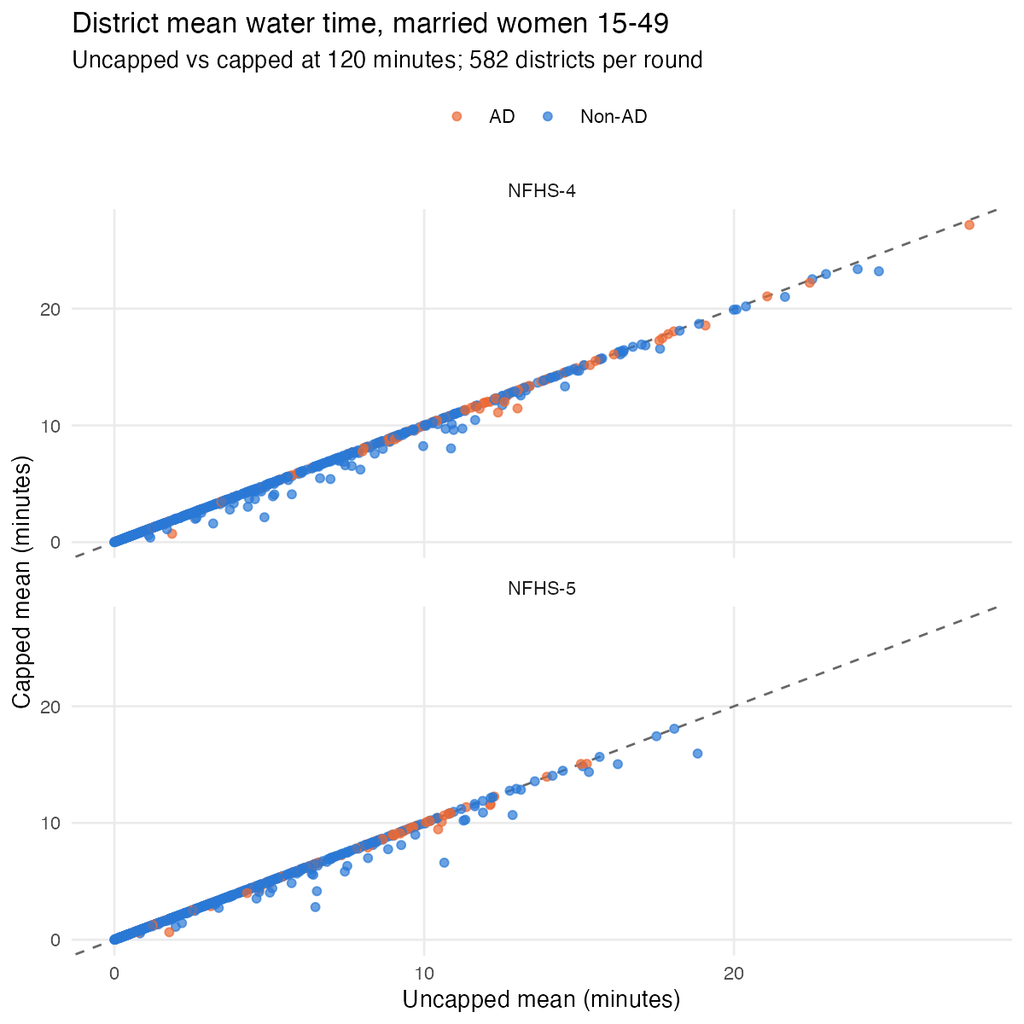

### appendix_water_time_distribution.png

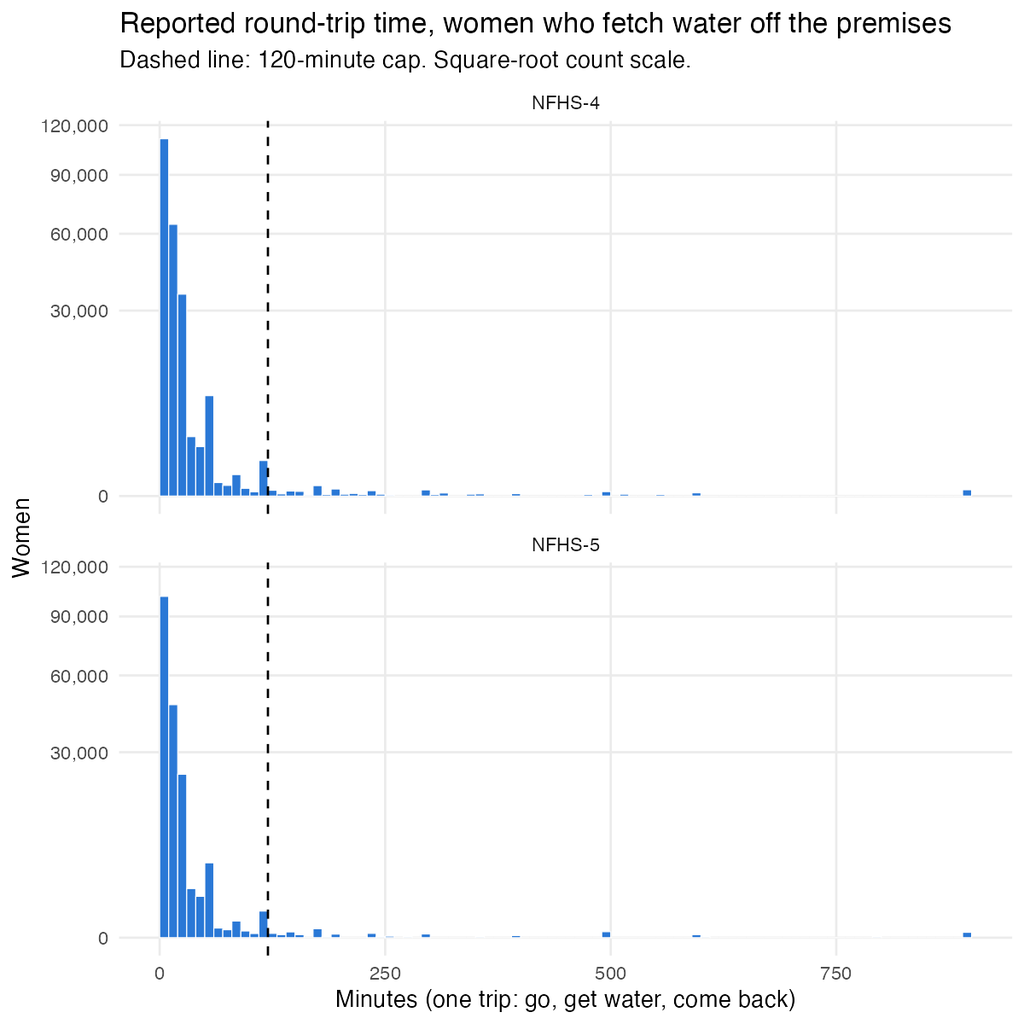

### att_coefficients_empowerment_full.png

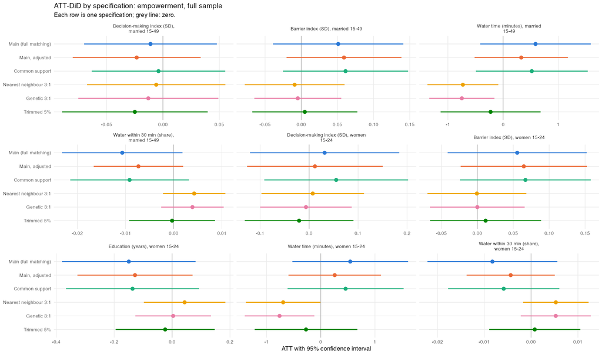

### att_coefficients_empowerment_precovid.png

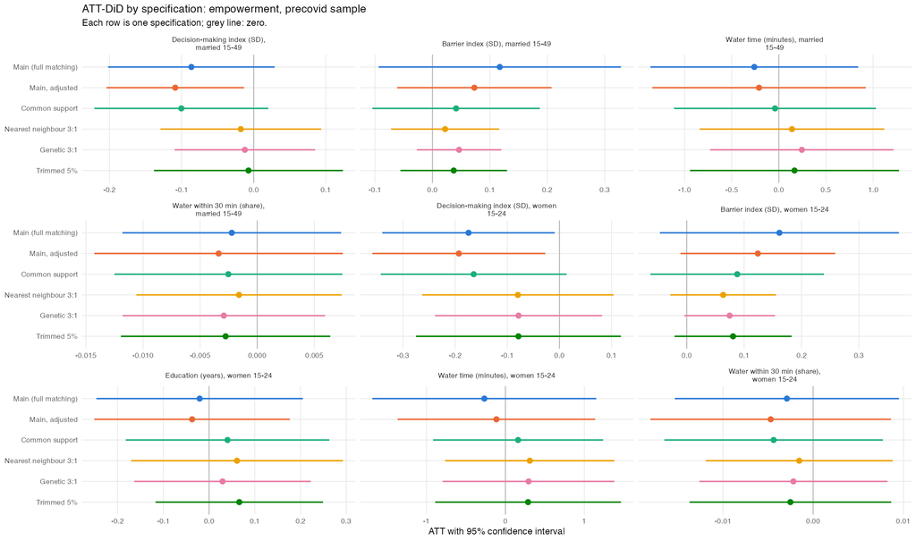

### att_coefficients_health_full.png

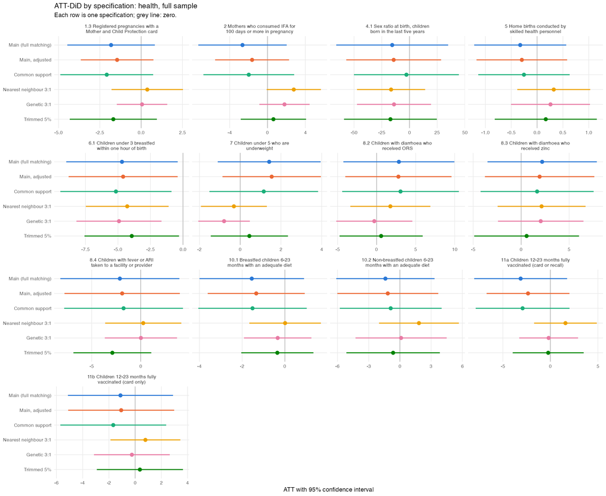

### att_coefficients_health_precovid.png

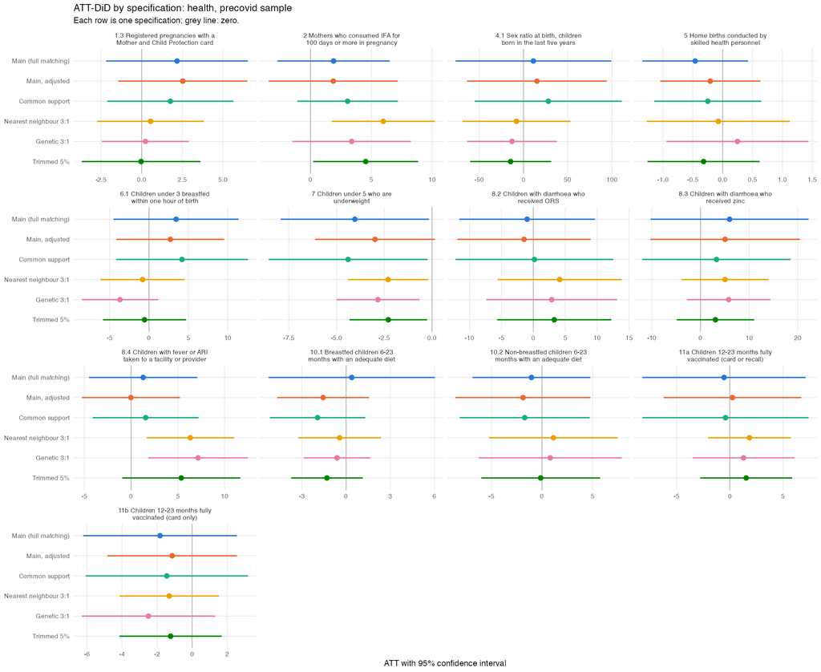

### att_loso_empowerment_full.png

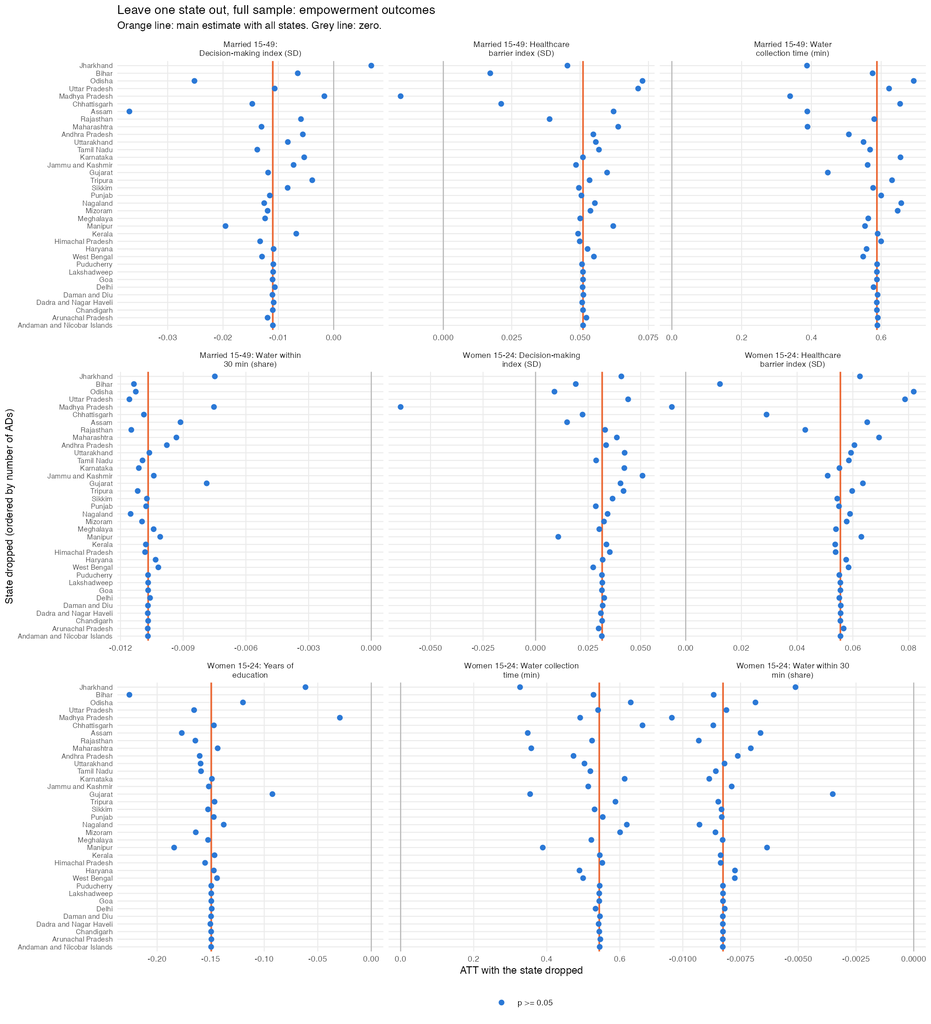

### att_loso_empowerment_precovid.png

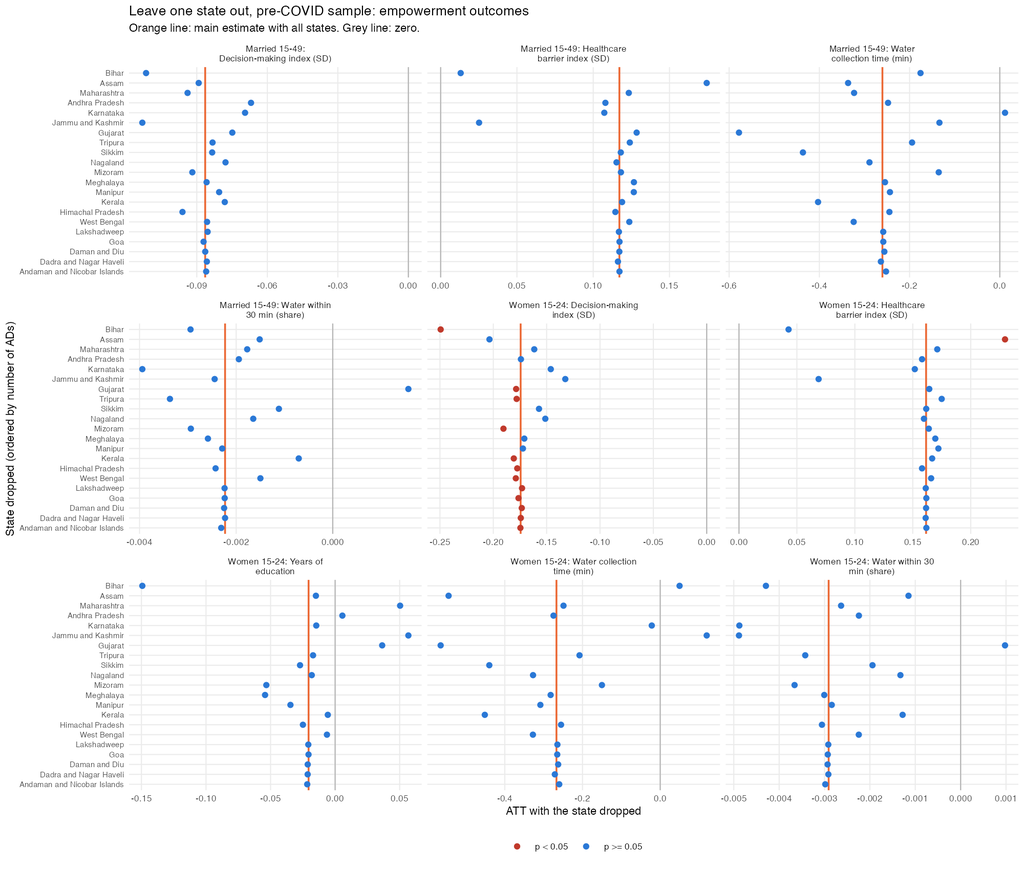

### att_loso_full.png

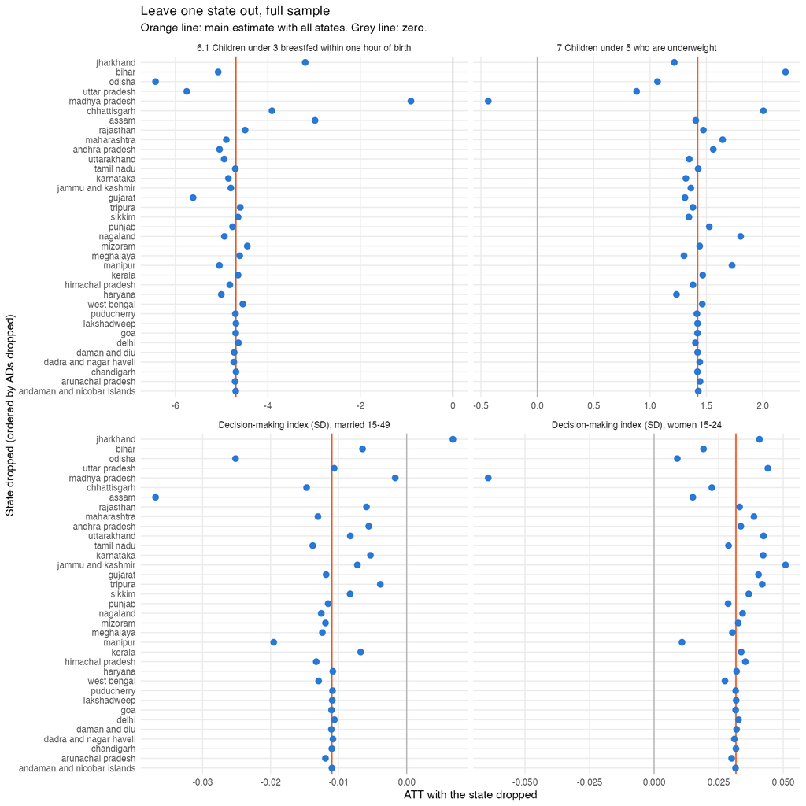

### att_loso_precovid.png

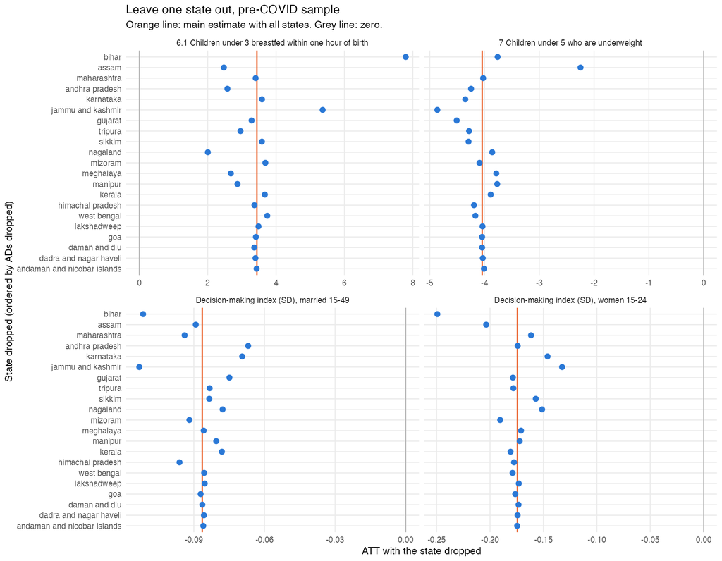

### att_permutation_empowerment_full.png

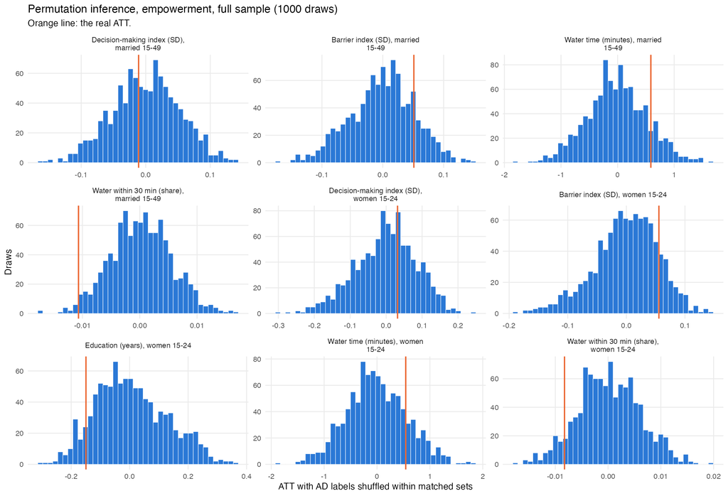

### att_permutation_empowerment_precovid.png

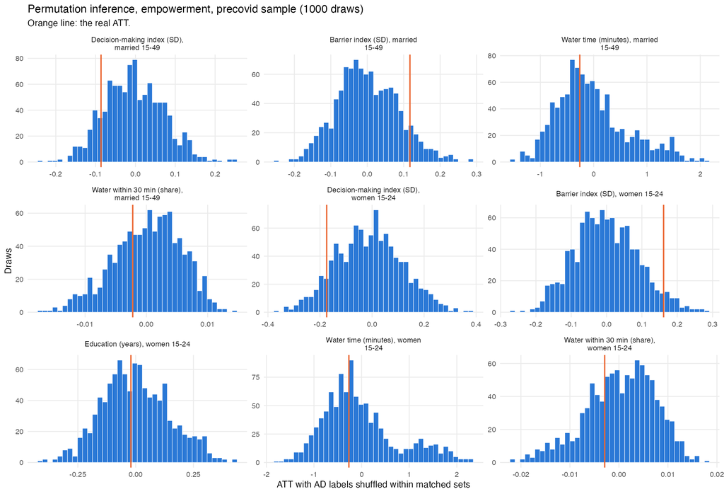

### att_permutation_health_full.png

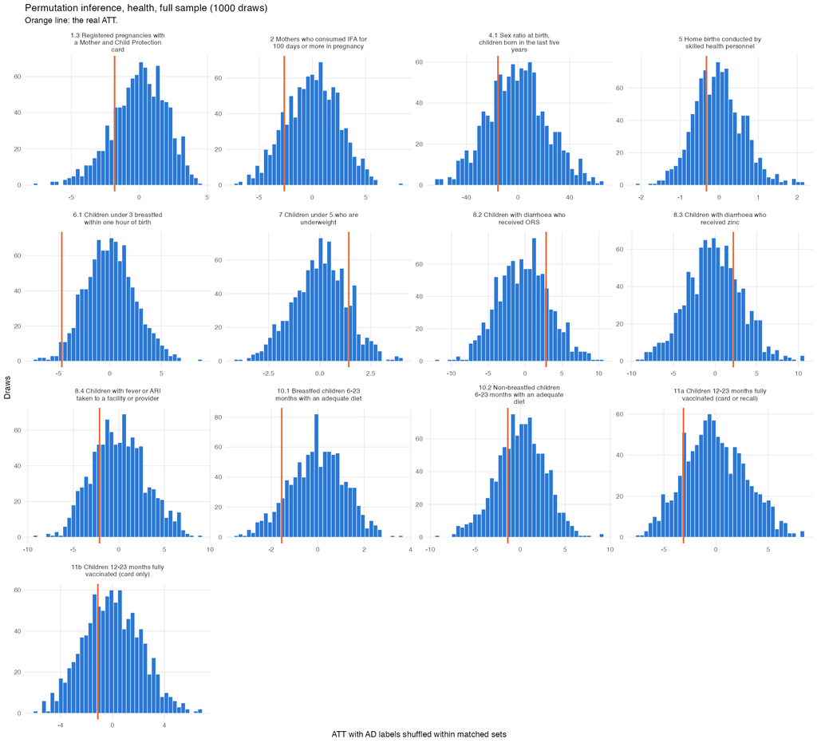

### att_permutation_health_precovid.png

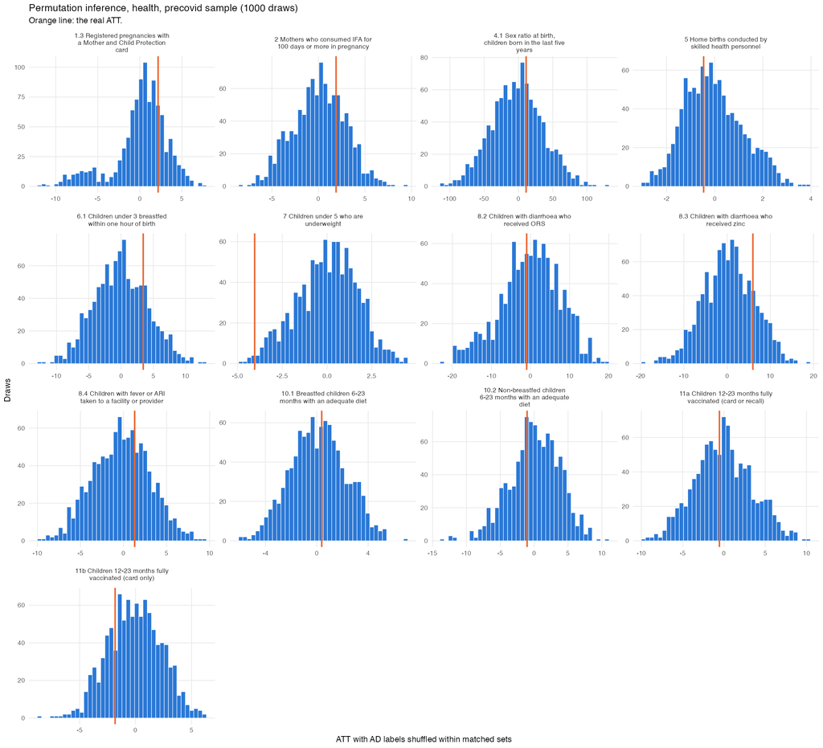

### match_balance_love_plot.png

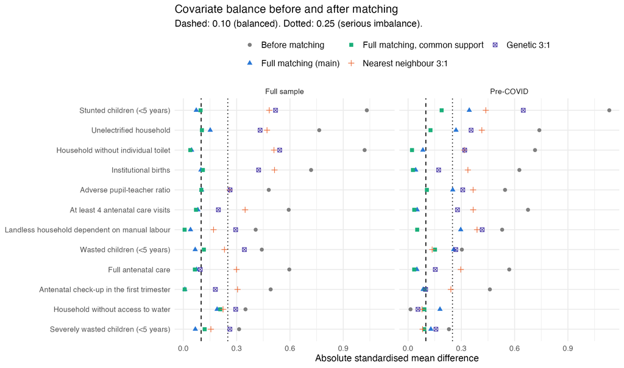

### match_densities_full.png

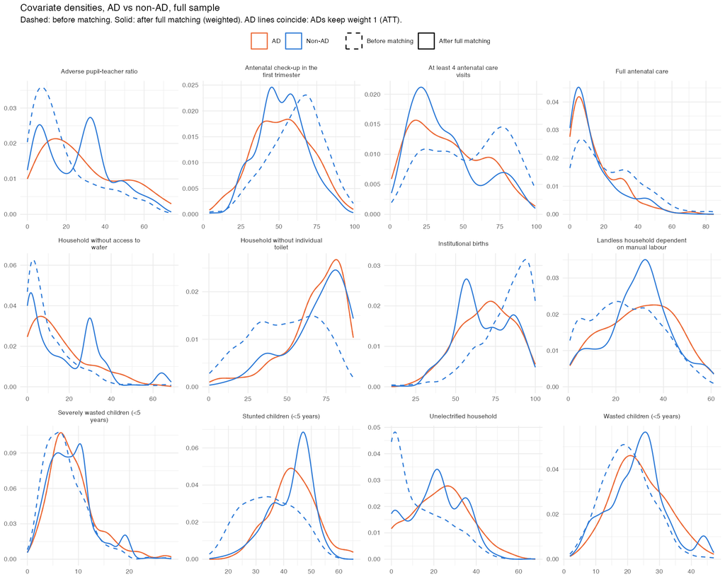

### match_densities_precovid.png

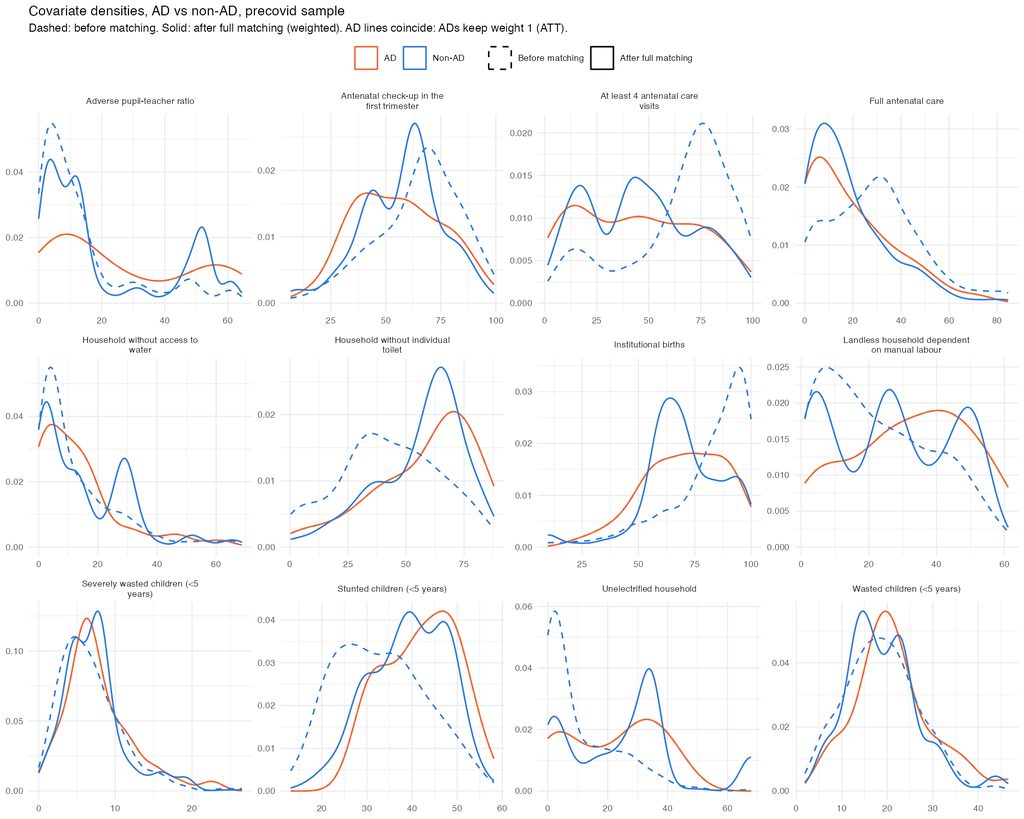